# National Economic Vitality & Market Momentum Roadmap (2024-2027)

An Executive Investment Strategy for Greener Pastures Real Estate Expansion

Author

Andrew Rea

Published

October 17, 2026

# 1. Executive Summary & Business Task

## Clear Statement of the Business Task

Greener Pastures, a national real estate chain, requires a rigorous, data-driven framework to evaluate and rank the top U.S. Metropolitan Statistical Areas (U.S. cities and their surrounding areas) for long-term strategic expansion.

The primary objective is to construct a **Composite Market Momentum Index** spanning 2024 through forward-looking projections to 2027. By synthesizing multi-agency federal datasets – specifically U.S. Census Bureau population drivers, Bureau of Labor Statistics (BLS) employment trends, and regional economic indicators – this analysis equips leadership with a quantitative foundation to:

- **Identify High-Conviction Growth Hubs:** Pinpoint markets demonstrating true economic acceleration versus transient migration hype.
- **Assess Macroeconomic Resilience:** Evaluate how local job creation and wealth dynamics protect capital allocations against structural downturns.
- **Optimize Capital Deployment:** Direct resources toward markets categorized by validated investment grades (ranging from Premium Expansion to Defensive Workforce Growth).

## Analytical Framework & Methodology Overview

To achieve a comprehensive market assessment, this project ingests, cleans, and joins disparate federal data sources into a unified scoring model. The evaluation rests upon three foundational pillars:

1. **Migration Velocity (40% Weight):** Measures net internal demographic flows per 1,000 residents to capture human capital concentration.
2. **Economic Pull (30% Weight):** Evaluates non-farm payroll expansions and local job growth percentages to confirm sustainable labor demand.
3. **Wealth Infusion (30% Weight):** Quantifies median income differentials (wealth gaps) to gauge the purchasing power and economic capacity of inbound populations.

Through rigorous data cleaning, anomaly patching, and a forward-looking momentum projection model, this report delivers a board-ready roadmap complete with a spatial visualization framework, a macro-resilience correlation analysis, and a downside stress-testing protocol for top-tier markets.

# 2. Environment Setup & Dependencies

To ensure the analysis environment is fully initialized, we begin by installing and loading the essential libraries required for data manipulation, Excel data handling, spatial mapping, and advanced data visualization.

```r
install.packages('tidyverse')

install.packages('janitor')

install.packages('sf')
install.packages('tigris')
install.packages('ggrepel')

library(tidyverse)
library(readxl)
library(janitor)
library(ggplot2)
library(scales)

library(sf)
library(tigris)
library(ggrepel)

# Enable caching for spatial boundary downloads for map visualizations
options(tigris_use_cache = TRUE)
```

# 3. Data Ingestion & Source Files

To perform this multi-year national analysis, we ingest raw CSV and Excel datasets encompassing employment records, population components of change, geographic mobility surveys, economic output (GDP), and regional price parities (RPP) spanning from 2021 through 2024.

**Show R Code**

```r
bls_annual_emp_data <- read_csv("bls_annual_employment_msa_2022_2026.csv")

comp_of_pop_change <- read_xlsx("CBSA-MET-EST2024-COMP_Cleaned.xlsx")

geo_mobility_2021 <- read_csv("geo_mobility_2021_cleaned - ACSST1Y2021.S0701-Data.csv")
geo_mobility_2022 <- read_csv("geo_mobility_2022_cleaned - ACSST1Y2022.S0701-Data.csv")
geo_mobility_2023 <- read_csv("geo_mobility_2023_cleaned - ACSST1Y2023.S0701-Data.csv")
geo_mobility_2024 <- read_csv("geo_mobility_2024_cleaned - ACSST1Y2024.S0701-Data.csv")

msa_gdp <- read_csv("msa_gdp_2022_2024_cleaned.csv")
msa_rpp <- read_csv("msa_rpp_2022_2024_cleaned.csv")

total_pop_2021 <- read_csv("total_pop_2021_cleaned - ACSDT1Y2021.B01003-Data.csv")
total_pop_2022 <- read_csv("total_pop_2022_cleaned - ACSDT1Y2022.B01003-Data.csv")
total_pop_2023 <- read_csv("total_pop_2023_cleaned - ACSDT1Y2023.B01003-Data.csv")
total_pop_2024 <- read_csv("total_pop_2024_cleaned - ACSDT1Y2024.B01003-Data.csv")
```

# 4. Data Cleaning & Standardization

## 4.1 Bureau of Labor Statistics (BLS) Employment Data

Our first major data-wrangling challenge involves the Bureau of Labor Statistics (BLS) annual employment records. While the core dataset provides granular monthly payroll numbers, it presents a structural hurdle common in federal economic data.

### 4.1.1 Identifying Missing Geographic Metadata

Before modifying the data, we inspect the raw dataframe structure. As shown in the abbreviated structure output below, the primary BLS annual employment dataset tracks payroll figures strictly by numeric `series_id` values – it contains **no geographic identifiers (`geo_id`) or human-readable metropolitan area names**.

**Show R Code**

```r
# Standardize column names to snake-case for initial inspection
bls_annual_emp_data_cleaned_cols <- bls_annual_emp_data %>%
  clean_names("snake")

# Inspect column names and data types to confirm the absence of geographic fields
tibble(
  Column_Name = names(bls_annual_emp_data_cleaned_cols),
  Data_Type = map_chr(bls_annual_emp_data_cleaned_cols, ~ class(.x)[1])
) %>%
  head(15)
```

```
# A tibble: 15 × 2
   Column_Name Data_Type
   <chr>       <chr>
 1 series_id   character
 2 jan_2022    numeric
 3 feb_2022    numeric
 4 mar_2022    numeric
 5 apr_2022    numeric
 6 may_2022    numeric
 7 jun_2022    numeric
 8 jul_2022    numeric
 9 aug_2022    numeric
10 sep_2022    numeric
11 oct_2022    numeric
12 nov_2022    numeric
13 dec_2022    numeric
14 annual_2022 numeric
15 jan_2023    numeric
```

To bridge this gap, we must pull in two auxiliary lookup files provided by the BLS State & Metro Employment system:

1. `sm.area` (`bls_annual_emp_msa_area_codes.tsv`): A directory mapping numeric area codes to official Metropolitan Statistical Area (MSA) names.
2. `sm.series` (`bls_annual_emp_series_ids_cleaned.tsv`): A relational cross-walk file linking individual `series_id` strings directly to their corresponding area codes.

### 4.1.2 Ingesting and Cleaning Area & Series Metadata

With the metadata files identified, we ingest them, filter out macro-aggregates (such as statewide totals), harmonize string formats, and build a unified cross-walk key (`series_name_key`) to successfully map geographic names back onto our employment figures.

**Show R Code**

```r
# Read supporting metadata files
bls_annual_emp_area_codes <- read.delim("bls_annual_emp_msa_area_codes.tsv",
                                        header = TRUE, sep = "\t",
                                        stringsAsFactors = FALSE)

bls_annual_emp_series_ids <- read.delim("bls_annual_emp_series_ids_cleaned.tsv",
                                        header = TRUE, sep = "\t",
                                        stringsAsFactors = FALSE)

# Clean the area codes table and standardize geographical text strings
bls_annual_emp_area_codes_cleaned <- bls_annual_emp_area_codes %>%
  filter(
    area_name != "Statewide",
    area_name != "All Metropolitan Statistical Areas"
  ) %>%
  mutate(
    area_code = as.character(area_code),
    geographic_area_name = tolower(area_name),
    geographic_area_name = str_remove(geographic_area_name, "^\\."),
    geographic_area_name = str_remove_all(geographic_area_name, "\\s*\\([^)]*\\)"),
    geographic_area_name = str_remove_all(geographic_area_name,
                                          "\\s(metro|micro|statistical)\\sarea"),
    geographic_area_name = str_remove(geographic_area_name,
                                      "\\s(msa|μsa|division|metropolitan division)"),
    geographic_area_name = str_replace_all(geographic_area_name, "[,/-]", " "),
    geographic_area_name = str_squish(geographic_area_name),
    geographic_area_name = str_remove(geographic_area_name, "[.,]$")
  ) %>%
  select(-area_name)

# Clean the series ID mapping table and harmonize prefixes (SMS to SMU)
bls_annual_emp_series_ids_cleaned <- bls_annual_emp_series_ids %>%
  filter(
    area_code != 0,
    area_code != 99999
  ) %>%
  mutate(
    area_code = as.character(area_code),
    series_id = trimws(series_id),
    series_id = gsub("^SMS", "SMU", series_id)
  ) %>%
  select(series_id, area_code) %>%
  distinct(series_id, .keep_all = TRUE)

# Merge metadata into a unified lookup key
series_name_key <- bls_annual_emp_series_ids_cleaned %>%
  inner_join(bls_annual_emp_area_codes_cleaned, by = "area_code") %>%
  select(series_id, "geo_id" = area_code, geographic_area_name)
```

### 4.1.3 Joining Employment Windows and Data Quality Validation

With our standardized lookup key (`series_name_key`) successfully mapped, we can now merge the geographic identifiers and human-readable area names back onto the core employment records.

To prepare for longitudinal analysis, we partition the data into rolling annual evaluation windows spanning 2022 through 2025, isolating the relevant monthly payroll columns for each timeframe. Finally, we execute a unified duplicate check to guarantee data integrity across the joined tables.

**Show R Code**

```r
# Joining the BLS datasets across rolling annual windows
bls_employment_data_2022_2023 <- bls_annual_emp_data_cleaned_cols %>%
  inner_join(series_name_key, by = "series_id") %>%
  select(series_id, geo_id, geographic_area_name, jan_2022:dec_2022, jan_2023:dec_2023)

bls_employment_data_2023_2024 <- bls_annual_emp_data_cleaned_cols %>%
  inner_join(series_name_key, by = "series_id") %>%
  select(series_id, geo_id, geographic_area_name, jan_2023:dec_2023, jan_2024:dec_2024)

bls_employment_data_2024_2025 <- bls_annual_emp_data_cleaned_cols %>%
  inner_join(series_name_key, by = "series_id") %>%
  select(series_id, geo_id, geographic_area_name, jan_2024:dec_2024, jan_2025:dec_2025)

# Verifying data integrity by checking for duplicate records
c(
  "2022_2023_duplicates" = any(duplicated(bls_employment_data_2022_2023)),
  "2023_2024_duplicates" = any(duplicated(bls_employment_data_2023_2024)),
  "2024_2025_duplicates" = any(duplicated(bls_employment_data_2024_2025))
)
```

```
2022_2023_duplicates 2023_2024_duplicates 2024_2025_duplicates
               FALSE                FALSE                FALSE
```

## 4.2 U.S. Census Bureau Components of Population Change Data

Following our BLS employment pipeline, we turn to the **U.S. Census Bureau Components of Population Change** dataset (`comp_of_pop_change`). This file tracks critical demographic shifts – such as net migration, natural increase, and international migration – across metropolitan areas.

### 4.2.1 Identifying Missing Geographic Identifiers and Type Anomalies

An initial inspection of the raw population change dataset via `glimpse()` reveals two critical hurdles: the complete lack of a native numeric geographic identifier, and the presence of visible  
`"(X)"` special characters within columns like `domestic_annual_change` and `domestic_`  
`cumulative_change`.

```r
# Inspect the structure to identify missing identifiers and character data types
glimpse(comp_of_pop_change)
```

```
Rows: 389
Columns: 15
$ geographic_area                    <chr> "United States", ".In Metropolitan …
$ total_population_annual_change     <dbl> 3304757, 3170217, 1440, 2115, -87, …
$ natural_annual_change              <dbl> 518638, 626841, 94, -1287, -125, -1…
$ births_annual_change               <dbl> 3605563, 3127037, 1995, 6552, 1675,…
$ deaths_annual_change               <dbl> 3086925, 2500196, 1901, 7839, 1800,…
$ total_annual_change                <dbl> 2786119, 2542749, 1347, 3399, 43, 1…
$ international_annual_change        <dbl> 2786119, 2670400, 1178, 3039, 232, …
$ domestic_annual_change             <chr> "(X)", "-127651.0", "169.0", "360.0…
$ total_population_cumulative_change <dbl> 8595252, 8179931, 7667, -2, -3463, …
$ natural_cumulative_change          <dbl> 1425410, 1988960, 303, -7402, -905,…
$ births_cumulative_change           <dbl> 15413421, 13356831, 9122, 28648, 71…
$ deaths_cumulative_change           <dbl> 13988011, 11367871, 8819, 36050, 80…
$ total_cumulative_change            <dbl> 7169842, 6195463, 7274, 7319, -2365…
$ international_cumulative_change    <dbl> 7169842, 6869418, 3113, 8247, 589, …
$ domestic_cumulative_change         <chr> "(X)", "-673955.0", "4161.0", "-928…
```

Because these special characters denote missing or suppressed values, they force R to treat numeric economic metrics as character data types.

To resolve the missing geographic identifier problem, we utilize a **Census Bureau Delineation File** (`delineation_file_cleaned - New List 1.csv`). This metadata file supplies official Core-Based Statistical Area (CBSA) codes and metropolitan titles, providing the exact geographic anchors needed to link our demographic metrics.

### 4.2.2 Ingesting and Cleaning the Delineation File

The following code chunk ingests the delineation file, renames and converts the CBSA codes into standardizing string `geo_id` fields, and applies rigorous string-cleaning regular expressions to harmonize the metropolitan area names for future cross-dataset joins.

**Show R Code**

```r
# Reading and storing the delineation file
delineation_file <- read_csv("delineation_file_cleaned - New List 1.csv")

# Cleaning the delineation file to prepare for joining
delineation_file_cleaned <- delineation_file %>%
  mutate(
    # Renaming and formatting the geographic identifier column
    geo_id = as.character(cbsa_code),

    # Standardizing geographic area names
    geographic_area_name = tolower(cbsa_title),
    geographic_area_name = str_remove(geographic_area_name, "^\\."),
    geographic_area_name = str_remove_all(geographic_area_name, "\\s*\\([^)]*\\)"),
    geographic_area_name = str_remove_all(geographic_area_name,
                                          "\\s(metro|micro|statistical)\\sarea"),
    geographic_area_name = str_remove_all(geographic_area_name,
                                          "\\s(msa|μsa|division|metropolitan division)"),
    geographic_area_name = str_replace_all(geographic_area_name, "[,/-]", " "),
    geographic_area_name = str_squish(geographic_area_name),
    geographic_area_name = str_remove(geographic_area_name, "[.,]$")
  ) %>%
  # Selecting necessary columns and ensuring unique records
  select(geo_id, geographic_area_name) %>%
  distinct(geo_id, .keep_all = TRUE)
```

### 4.2.3 Cleaning Special Characters and Structuring Population Data

Before joining our cleaned Census Delineation File, we must audit for any hidden anomalous characters, sanitize the geographic labels, parse the character columns into true numeric metrics using `parse_number()`, and reorder our identifier columns for optimal readability.

**Show R Code**

```r
# Step 1: Audit and isolate unique special characters across domestic columns
comp_of_pop_change %>%
  select(starts_with("domestic_")) %>%
  pivot_longer(everything()) %>%
  filter(!value %in% "(X)") %>%
  filter(is.na(as.numeric(value))) %>%
  distinct(value)

# Step 2: Clean the dataset, filter aggregates, and parse special characters to numeric
comp_of_pop_change_cleaned <- comp_of_pop_change %>%
  filter(
    geographic_area != "United States",
    geographic_area != ".In Metropolitan Statistical Area",
    !str_detect(geographic_area, "^\\s*State of")
  ) %>%
  # Standardize geographic area names
  mutate(
    geographic_area_name = tolower(geographic_area),
    geographic_area_name = str_remove(geographic_area_name, "^\\."),
    geographic_area_name = str_remove_all(geographic_area_name, "\\s*\\([^)]*\\)"),
    geographic_area_name = str_remove_all(geographic_area_name,
                                          "\\s(metro|micro|statistical)\\sarea"),
    geographic_area_name = str_remove_all(geographic_area_name,
                                          "\\s(msa|μsa|division|metropolitan division)"),
    geographic_area_name = str_replace_all(geographic_area_name, "[,/-]", " "),
    geographic_area_name = str_squish(geographic_area_name),
    geographic_area_name = str_remove(geographic_area_name, "[.,]$")
  ) %>%
  # Target character columns, map "(X)" to NA, and convert to numeric
  mutate(across(
    .cols = starts_with("domestic_"),
    .fns = ~ parse_number(as.character(.x), na = "(X)")
  )) %>%
  select(-geographic_area)

# Step 3: Relocate the standardized name column to the front for readability
comp_of_pop_change_cleaned <- comp_of_pop_change_cleaned %>%
  relocate(geographic_area_name, .before = total_population_annual_change)
```

### 4.2.4 Merging Geographic Identifiers and Data Validation

With both our population change dataset and our Census Delineation File cleaned and standardized, we perform a final text-matching validation on the geographic area names to ensure high fidelity before joining.

Once verified, we execute a left join to attach the official `geo_id` numbers, relocate the identifier to the front of the dataframe for clean structuring, and run rigorous validation checks to confirm zero duplicates and verify the data type and charaacter length of our new primary keys.

**Show R Code**

```r
# Join the delineation file to attach official geographic identifiers
comp_of_pop_change_identifier <- comp_of_pop_change_cleaned %>%
  left_join(delineation_file_cleaned, by = "geographic_area_name") %>%
  relocate(geo_id, .before = geographic_area_name)

# --- Data Integrity & Structure Audit ---

# Check for duplicate rows, and audit the class, uniqueness, and string length of the
# identifiers, and gather those metrics into variables
dup_check <- any(duplicated(comp_of_pop_change_identifier))
id_class <- class(comp_of_pop_change_identifier$geo_id)
unique_count <- length(unique(comp_of_pop_change_identifier$geo_id))
id_lengths <- paste(nchar(comp_of_pop_change_identifier$geo_id[1:5]), collapse = ", ")

# Print the gathered metrics as a single output block
cat(
  "--- Components of Population Change: Validation Audit ---\n",
  "Duplicate Rows Detected?:", dup_check, "\n",
  "Identifier Data Type:", id_class, "\n",
  "Unique Geographic Areas (Count):", unique_count, "\n",
  "Sample Identifier Lengths (First 5):", id_lengths, "\n"
)
```

```
--- Components of Population Change: Validation Audit ---
 Duplicate Rows Detected?: FALSE
 Identifier Data Type: character
 Unique Geographic Areas (Count): 387
 Sample Identifier Lengths (First 5): 5, 5, 5, 5, 5
```

## 4.3 U.S. Census Bureau Geographic Mobility Data (2021-2024)

Our next analytical focus centers on the American Community Survey (ACS) Geographic Mobility datasets spanning 2021 through 2024. These files capture crucial migration flows detailing whether residents moved within the same county, across county lines, or from out of state.

### 4.3.1 Standardizing and Cleaning the 2021 Mobility Dataset

Similar to our previous datasets, an initial audit of `geo_mobility_2021` reveals formatting hurdles: raw geographic identifier strings embedded with prefix text (`US`), unformatted metropolitan names, and special character strings (`"null"`, `"N"`) causing numeric metrics to default to character data types.

To resolve this, we perform a specialized character audit, extract a clean 5-digit `geo_id`, standardize the geographic names using our established regex pipeline, and utilize `parse_number()` to map all anomalous strings to proper `NA` numeric values.

**Show R Code**

```r
# Step 1: Consolidate and extract the unique special characters within the 2021 Geographic Mobility
# dataset
geo_anomalies_2021 <- geo_mobility_2021 %>% select(starts_with("S0701_")) %>%
  pivot_longer(everything()) %>% filter(!value %in% c("null", "N")) %>%
  filter(is.na(as.numeric(value))) %>% distinct(value)

# Step 2: Clean and transform the 2021 geographic mobility dataset
geo_mobility_2021_cleaned <- geo_mobility_2021 %>%
  mutate(
    # Extract the clean 5-digit geographic identifier
    geo_id = str_extract(geo_id, "(?<=US)\\d{5}$"),

    # Standardize geographic area names
    geographic_area_name = tolower(geographic_area_name),
    geographic_area_name = str_remove(geographic_area_name, "^\\."),
    geographic_area_name = str_remove_all(geographic_area_name, "\\s*\\([^)]*\\)"),
    geographic_area_name = str_remove_all(geographic_area_name,
                                          "\\s(metro|micro|statistical)\\sarea"),
    geographic_area_name = str_remove_all(geographic_area_name,
                                          "\\s(msa|μsa|division|metropolitan division)"),
    geographic_area_name = str_replace_all(geographic_area_name, "[,/-]", " "),
    geographic_area_name = str_squish(geographic_area_name),
    geographic_area_name = str_remove(geographic_area_name, "[.,]$")
  ) %>%
  # Target survey columns, parse special strings to NA, and convert to numeric
  mutate(across(
    .cols = starts_with("S0701_"),
    .fns = ~ parse_number(as.character(.), na = c("null", "N", "(X)", "-", "**", "***", "*****"))
  ))

# Step 3: Call and print the unique special characters in the 2021 Geographic Mobility dataset
# (Code snippet placed here to prevent multiple "code-summary" prompts in the document.)
cat(
  "=== 2021 Geographic Mobility Dataset: Special Character Audit ===\n",
  "Anomalies Found:", paste(geo_anomalies_2021, collapse = ", "), "\n"
)
```

```
=== 2021 Geographic Mobility Dataset: Special Character Audit ===
 Anomalies Found: c("(X)", "-", "**", "2,500-", "***", "*****")
```

### 4.3.2 Replicating the Pipeline for 2022, 2023, and 2024

To maintain temporal consistency, we apply our standardization and special character parsing pipeline to the remaining 2022, 2023, and 2024 ACS mobility datasets. Before transforming each year, we execute a quick structural audit to confirm that no new anomalous string values have been introduced across the survey releases.

**Show R Code**

```r
# Consolidate and extract the unique special characters across the remaining subsequent years
geo_anomalies_2022 <- geo_mobility_2022 %>% select(starts_with("S0701_")) %>%
  pivot_longer(everything()) %>% filter(!value %in% c("null", "N")) %>%
  filter(is.na(as.numeric(value))) %>% distinct(value)

geo_anomalies_2023 <- geo_mobility_2023 %>% select(starts_with("S0701_")) %>%
  pivot_longer(everything()) %>% filter(!value %in% c("null", "N")) %>%
  filter(is.na(as.numeric(value))) %>% distinct(value)

geo_anomalies_2024 <- geo_mobility_2024 %>% select(starts_with("S0701_")) %>%
  pivot_longer(everything()) %>% filter(!value %in% c("null", "N")) %>%
  filter(is.na(as.numeric(value))) %>% distinct(value)

geo_mobility_2022_cleaned <- geo_mobility_2022 %>%
  mutate(
    geo_id = str_extract(geo_id, "(?<=US)\\d{5}$"),
    geographic_area_name = tolower(geographic_area_name),
    geographic_area_name = str_remove(geographic_area_name, "^\\."),
    geographic_area_name = str_remove_all(geographic_area_name,
                                          "\\s(metro|micro|statistical)\\sarea"),
    geographic_area_name = str_remove_all(geographic_area_name,
                                          "\\s(msa|μsa|division|metropolitan division)"),
    geographic_area_name = str_replace_all(geographic_area_name, "[,/-]", " "),
    geographic_area_name = str_squish(geographic_area_name),
    geographic_area_name = str_remove(geographic_area_name, "[.,]$")
  ) %>%
  mutate(across(
    .cols = starts_with("S0701_"),
    .fns = ~ parse_number(as.character(.), na = c("null", "N", "(X)", "-", "**", "***", "*****"))
  ))

geo_mobility_2023_cleaned <- geo_mobility_2023 %>%
  mutate(
    geo_id = str_extract(geo_id, "(?<=US)\\d{5}$"),
    geographic_area_name = tolower(geographic_area_name),
    geographic_area_name = str_remove(geographic_area_name, "^\\."),
    geographic_area_name = str_remove_all(geographic_area_name,
                                          "\\s(metro|micro|statistical)\\sarea"),
    geographic_area_name = str_remove_all(geographic_area_name,
                                          "\\s(msa|μsa|division|metropolitan division)"),
    geographic_area_name = str_replace_all(geographic_area_name, "[,/-]", " "),
    geographic_area_name = str_squish(geographic_area_name),
    geographic_area_name = str_remove(geographic_area_name, "[.,]$")
  ) %>%
  mutate(across(
    .cols = starts_with("S0701_"),
    .fns = ~ parse_number(as.character(.), na = c("null", "N", "(X)", "-", "**", "***", "*****"))
  ))

geo_mobility_2024_cleaned <- geo_mobility_2024 %>%
  mutate(
    geo_id = str_extract(geo_id, "(?<=US)\\d{5}$"),
    geographic_area_name = tolower(geographic_area_name),
    geographic_area_name = str_remove(geographic_area_name, "^\\."),
    geographic_area_name = str_remove_all(geographic_area_name,
                                          "\\s(metro|micro|statistical)\\sarea"),
    geographic_area_name = str_remove_all(geographic_area_name,
                                          "\\s(msa|μsa|division|metropolitan division)"),
    geographic_area_name = str_replace_all(geographic_area_name, "[,/-]", " "),
    geographic_area_name = str_squish(geographic_area_name),
    geographic_area_name = str_remove(geographic_area_name, "[.,]$")
  ) %>%
  mutate(across(
    .cols = starts_with("S0701_"),
    .fns = ~ parse_number(as.character(.), na = c("null", "N", "(X)", "-", "**", "***", "*****"))
  ))

# Call the unique special characters and print a clean, descriptive unified output block
# (Code snippet placed here to prevent multiple "code-summary" prompts in the document.)
cat(
  "=== Geographic Mobility Dataset: Special Character Audit ===\n",
  "2022 Anomalies Found:", paste(geo_anomalies_2022, collapse = ", "), "\n",
  "2023 Anomalies Found:", paste(geo_anomalies_2023, collapse = ", "), "\n",
  "2024 Anomalies Found:", paste(geo_anomalies_2024, collapse = ", "), "\n"
)
```

```
=== Geographic Mobility Dataset: Special Character Audit ===
 2022 Anomalies Found: c("(X)", "-", "**", "*****", "2,500-", "***")
 2023 Anomalies Found: c("(X)", "-", "**", "2,500-", "***", "*****")
 2024 Anomalies Found: c("(X)", "-", "**", "2,500-", "***", "*****")
```

## 4.4 Bureau of Economic Analysis (BEA) GDP Data

To evaluate economic momentum, we integrate Gross Domestic Product (GDP) metrics from the Bureau of Economic Analysis (BEA).

As of February 2026, the BEA has officially discontinued the publication of pre-calculated metropolitan statistical area (MSA) data for several core tables, supplying raw county-level records instead. To bridge this gap, we leverage our Census Bureau Delineation File to build a robust county-to-MSA crosswalk, allowing us to accurately aggregate county figures back up to metropolitan areas.

### 4.4.1 Preparing the Delineation File for County-to-MSA Aggregation

The code below processes the raw delineation file by combining FIPS state and county codes to establish matching county identifiers, standardizing county text fields, and aligning our core MSA geographic names for seamless merging with the BEA GDP tables.

**Show R Code**

```r
# Cleaning the delineation file to create a county-to-MSA crosswalk for GDP data
cleaned_delineation_file_for_gdp <- delineation_file %>%
  mutate(
    # Construct a 5-digit county FIPS code to match the BEA dataset
    county_code = paste0(fips_state_code, fips_county_code),

    # Format the geographic identifier and convert to character
    geo_id = as.character(cbsa_code),

    # Standardize county names for validation
    county_name = tolower(county_or_county_equivalent),
    county_name = str_remove_all(county_name,
                                 "\\s(county|parish|municipality|census area|borough)"),
    county_name = str_replace_all(county_name, "[,/-]", " "),
    county_name = str_squish(county_name),

    # Standardize metropolitan geographic area names
    geographic_area_name = tolower(cbsa_title),
    geographic_area_name = str_remove(geographic_area_name, "^\\."),
    geographic_area_name = str_remove_all(geographic_area_name, "\\s*\\([^)]*\\)"),
    geographic_area_name = str_remove_all(geographic_area_name,
                                          "\\s(metro|micro|statistical)\\sarea"),
    geographic_area_name = str_remove_all(geographic_area_name,
                                          "\\s(msa|μsa|division|metropolitan division)"),
    geographic_area_name = str_replace_all(geographic_area_name, "[,/-]", " "),
    geographic_area_name = str_squish(geographic_area_name),
    geographic_area_name = str_remove(geographic_area_name, "[.,]$")
  ) %>%
  # Select necessary mapping columns and fix source typo in column name
  select(
    county_code,
    county_name,
    geo_id,
    geographic_area_name,
    "metropolitan_micropolitan_statistical_area" = metropolitan_micropolitan_statisitcal_area
  )
```

### 4.4.2 Auditing and Cleaning the BEA County GDP Dataset

With our delineation crosswalk prepared, we turn to the raw county-level BEA GDP dataset (`msa_gdp`). Because economic datasets frequently contain suppressed or missing records denoted by special character strings, we first execute an audit across the yearly columns to identify any anomalous text values before reshaping and cleaning the table.

**Show R Code**

```r
# Step 1: Audit non-numeric special characters in the yearly GDP columns
msa_gdp %>%
  select(-starts_with("geo_")) %>%
  pivot_longer(everything()) %>%
  filter(is.na(as.numeric(value))) %>%
  filter(!is.na(value)) %>%
  distinct(value) %>%
  print(n = Inf)

# Step 2: Clean, reshape, and parse the county GDP dataset
msa_gdp_cleaned <- msa_gdp %>%
  # Standardize the geographic FIPS identifier to match our crosswalk
  rename(county_code = geo_fips) %>%

  # Reshape from wide to long format for longitudinal panel analysis
  pivot_longer(
    cols = c(`2022`, `2023`, `2024`),
    names_to = "year",
    values_to = "gdp"
  ) %>%
  mutate(
    # Convert year strings to numeric
    year = as.numeric(year),

    # Map special character suppressions to true NA values and parse to numeric
    gdp = na_if(gdp, "(NA)"),
    gdp = as.numeric(gdp),

    # Extract and clean county names for crosswalk validation
    county_name = str_split_i(geo_name, ",", 1),
    county_name = tolower(county_name),
    county_name = str_remove_all(county_name, "\\*"),
    county_name = str_remove_all(county_name,
                                 "\\s(county|parish|municipality|census area|borough)"),
    county_name = str_replace_all(county_name, "[,/-]", " "),
    county_name = str_squish(county_name)
  ) %>%
  # Retain only necessary analytical columns
  select(county_code, county_name, year, gdp)
```

### 4.4.3 Merging County Records and Aggregating Metropolitan GDP

With our county-level GDP data cleaned and our delineation crosswalk prepared, we perform a string-matching validation across both tables to ensure high fidelity before joining.

Once verified, we execute a left join using the unique 5-digit county FIPS codes (`county_code`), filter specifically for **Metropolitan Statistical Areas (MSAs)**, and aggregate the underlying county GDP figures into a unified annual total for each metropolitan region, and run a final integrity check for duplicate records.

**Show R Code**

```r
# Step 1: Validate county name structures and string alignment across both dataframes
sample_county_str <- capture.output(str(cleaned_delineation_file_for_gdp$county_name))
sample_county_str <- sample_county_str[1]

match_check <- c("edmunds", "grays harbor", "callahan", "jones", "taylor") %in%
  msa_gdp_cleaned$county_name

# Step 2: Join county GDP records to the delineation crosswalk and aggregate to MSA level
msa_gdp_geo_area_names <- msa_gdp_cleaned %>%
  # Join using the standardized county FIPS code
  left_join(cleaned_delineation_file_for_gdp, by = "county_code") %>%
  # Filter exclusively for Metropolitan Statistical Areas
  filter(metropolitan_micropolitan_statistical_area == "Metropolitan Statistical Area") %>%
  # Aggregate county-level figures into a total metropolitan GDP sum per year
  group_by(geo_id, geographic_area_name, year) %>%
  summarize(total_msa_gdp = sum(gdp, na.rm = TRUE), .groups = "drop")

# Step 3: Verify data integrity by checking for duplicate rows
gdp_duplicates <- any(duplicated(msa_gdp_geo_area_names))

# Step 4: Print a single unified, descriptive validation output
cat(
  "=== BEA GDP Crosswalk: String Validation & Integrity Audit ===\n",
  "Delineation County Structure:", sample_county_str, "\n",
  "Target County Matches Found (edmunds, grays harbor, callahan, jones, taylor):", paste(
    match_check, collapse = ", "
  ), "\n",
  "Duplicate Rows Detected?:", gdp_duplicates, "\n",
  "Final Aggregated MSA Rows Created:", nrow(msa_gdp_geo_area_names), "\n"
)
```

```
=== BEA GDP Crosswalk: String Validation & Integrity Audit ===
 Delineation County Structure:  chr [1:1915] "brown" "edmunds" "grays harbor" "callahan" "jones" "taylor" ...
 Target County Matches Found (edmunds, grays harbor, callahan, jones, taylor): TRUE, TRUE, TRUE, TRUE, TRUE
 Duplicate Rows Detected?: FALSE
 Final Aggregated MSA Rows Created: 1152
```

## 4.5 Bureau of Economic Analysis Regional Price Parities (RPP) Data

To account for geographic cost-of-living differences across metropolitan regions, we incorporate Regional Price Parities (RPP) data from the Bureau of Economic Analysis.

Unlike our previous GDP dataset, the raw RPP file already includes native geographic identifiers (`geo_fips`), and its annual metrics are stored cleanly as numeric types. Our cleaning pipeline focuses on filtering out national summary rows, reshaping the dataset from wide to long format for longitudinal analysis, applying our standard regex cleaning rules to the geographic area names, and reordering the columns for optimal structure.

**Show R Code**

```r
# Clean, reshape, and standardize the BEA Regional Price Parities dataset
msa_rpp_cleaned <- msa_rpp %>%
  # Standardize the geographic identifier column name
  rename(geo_id = geo_fips) %>%

  # Filter out national aggregate summary rows
  # ("00000" = US Total; "00998" = US Metro Portion; "00999" = US Metro Area)
  filter(!geo_id %in% c("00000", "00998", "00999")) %>%

  # Reshape data from wide to long format for multi-year panel analysis
  pivot_longer(
    cols = c(`2022`, `2023`, `2024`),
    names_to = "year",
    values_to = "rpp"
  ) %>%

  # Standardize and clean geographic area names
  mutate(
    geographic_area_name = tolower(geo_name),
    geographic_area_name = str_remove_all(geographic_area_name, "\\*"),
    geographic_area_name = str_remove(geographic_area_name, "^\\."),
    geographic_area_name = str_remove_all(geographic_area_name, "\\s*\\([^)]*\\)"),
    geographic_area_name = str_remove_all(geographic_area_name,
                                          "\\s(metro|micro|statistical)\\sarea"),
    geographic_area_name = str_remove_all(geographic_area_name,
                                          "\\s(msa|μsa|division|metropolitan division)"),
    geographic_area_name = str_replace_all(geographic_area_name, "[,/-]", " "),
    geographic_area_name = str_squish(geographic_area_name),
    geographic_area_name = str_remove(geographic_area_name, "[.,]$"),

    # Convert year strings back to numeric format after pivot
    year = as.numeric(year)
  ) %>%
  # Remove the original uncleaned name column
  select(-geo_name) %>%
  # Relocate the cleaned geographic name column for clean dataframe structure
  relocate(geographic_area_name, .before = year)
```

## 4.6 U.S. Census Bureau Total Population Data (2021-2024)

To provide the foundational demographic baseline for our economic and migration analysis, we process the American Community Survey (ACS) Total Population datasets spanning 2021 through 2024.

### 4.6.1 Standardizing and Cleaning the 2021 Total Population Dataset

An initial structural audit of `total_pop_2021` reveals that the `total_population_margin_`  
`of_error` column is defaulting to character data types due to survey suppression symbols (such as `"*****"`). We perform a targeted special character search to verify these anomalies, extract our clean 5-digit `geo_id` string, apply our standardized geographic regex pipeline, and parse the margin of error values into clean numeric formats.

**Show R Code**

```r
# Step 1: Consolidate and extract the unique special characters within the 2021 Total Population
# dataset
pop_anomalies_2021 <- total_pop_2021 %>%
  select(total_population_margin_of_error) %>%
  filter(!total_population_margin_of_error %in% "*****") %>%
  filter(is.na(as.numeric(total_population_margin_of_error))) %>%
  distinct(total_population_margin_of_error)

# Step 2: Clean and transform the 2021 total population dataset
total_pop_2021_cleaned <- total_pop_2021 %>%
  mutate(
    # Extract the clean 5-digit geographic identifier
    geo_id = str_extract(geo_id, "(?<=US)\\d{5}$"),

    # Standardize geographic area names
    geographic_area_name = tolower(geographic_area_name),
    geographic_area_name = str_remove(geographic_area_name, "^\\."),
    geographic_area_name = str_remove_all(geographic_area_name, "\\s*\\([^)]*\\)"),
    geographic_area_name = str_remove_all(geographic_area_name,
                                          "\\s(metro|micro|statistical)\\sarea"),
    geographic_area_name = str_remove_all(geographic_area_name,
                                          "\\s(msa|μsa|division|metropolitan division)"),
    geographic_area_name = str_replace_all(geographic_area_name, "[,/-]", " "),
    geographic_area_name = str_squish(geographic_area_name),
    geographic_area_name = str_remove(geographic_area_name, "[.,]$"),

    # Map suppression symbols to true NA values and convert to numeric
    total_population_margin_of_error = na_if(total_population_margin_of_error, "*****"),
    total_population_margin_of_error = as.numeric(total_population_margin_of_error)
  )

# Step 3: Call and print the unique special characters in the 2021 Total Population dataset
# (Code snippet placed here to prevent multiple "code-summary" prompts in the document.)
cat(
  "=== 2021 Total Population Dataset: Special Character Audit ===\n",
  "Anomalies Found:", paste(pop_anomalies_2021, collapse = ", "), "\n"
)
```

```
=== 2021 Total Population Dataset: Special Character Audit ===
 Anomalies Found: character(0)
```

### 4.6.2 Replicating the Pipeline for 2022, 2023, and 2024

To maintain full longitudinal consistency across our demographic baseline, we perform a special character audit across the remaining 2022, 2023, and 2024 American Community Survey Total Population datasets. Once verified, we apply the exact same identifier extraction, regex geographic name standardization, and suppression-to-numeric parsing pipeline.

**Show R Code**

```r
# Consolidate and extract unique special characters across the remaining three years
pop_anomalies_2022 <- total_pop_2022 %>%
  select(total_population_margin_of_error) %>%
  filter(!total_population_margin_of_error %in% "*****") %>%
  filter(is.na(as.numeric(total_population_margin_of_error))) %>%
  distinct(total_population_margin_of_error)

pop_anomalies_2023 <- total_pop_2023 %>%
  select(total_population_margin_of_error) %>%
  filter(!total_population_margin_of_error %in% "*****") %>%
  filter(is.na(as.numeric(total_population_margin_of_error))) %>%
  distinct(total_population_margin_of_error)

pop_anomalies_2024 <- total_pop_2024 %>%
  select(total_population_margin_of_error) %>%
  filter(!total_population_margin_of_error %in% "*****") %>%
  filter(is.na(as.numeric(total_population_margin_of_error))) %>%
  distinct(total_population_margin_of_error)

total_pop_2022_cleaned <- total_pop_2022 %>%
  mutate(
    geo_id = str_extract(geo_id, "(?<=US)\\d{5}$"),
    geographic_area_name = tolower(geographic_area_name),
    geographic_area_name = str_remove(geographic_area_name, "^\\."),
    geographic_area_name = str_remove_all(geographic_area_name, "\\s*\\([^)]*\\)"),
    geographic_area_name = str_remove_all(geographic_area_name,
                                          "\\s(metro|micro|statistical)\\sarea"),
    geographic_area_name = str_remove_all(geographic_area_name,
                                          "\\s(msa|μsa|division|metropolitan division)"),
    geographic_area_name = str_replace_all(geographic_area_name, "[,/-]", " "),
    geographic_area_name = str_squish(geographic_area_name),
    geographic_area_name = str_remove(geographic_area_name, "[.,]$"),
    total_population_margin_of_error = na_if(total_population_margin_of_error, "*****"),
    total_population_margin_of_error = as.numeric(total_population_margin_of_error)
  )

total_pop_2023_cleaned <- total_pop_2023 %>%
  mutate(
    geo_id = str_extract(geo_id, "(?<=US)\\d{5}$"),
    geographic_area_name = tolower(geographic_area_name),
    geographic_area_name = str_remove(geographic_area_name, "^\\."),
    geographic_area_name = str_remove_all(geographic_area_name, "\\s*\\([^)]*\\)"),
    geographic_area_name = str_remove_all(geographic_area_name,
                                          "\\s(metro|micro|statistical)\\sarea"),
    geographic_area_name = str_remove_all(geographic_area_name,
                                          "\\s(msa|μsa|division|metropolitan division)"),
    geographic_area_name = str_replace_all(geographic_area_name, "[,/-]", " "),
    geographic_area_name = str_squish(geographic_area_name),
    geographic_area_name = str_remove(geographic_area_name, "[.,]$"),
    total_population_margin_of_error = na_if(total_population_margin_of_error, "*****"),
    total_population_margin_of_error = as.numeric(total_population_margin_of_error)
  )

total_pop_2024_cleaned <- total_pop_2024 %>%
  mutate(
    geo_id = str_extract(geo_id, "(?<=US)\\d{5}$"),
    geographic_area_name = tolower(geographic_area_name),
    geographic_area_name = str_remove(geographic_area_name, "^\\."),
    geographic_area_name = str_remove_all(geographic_area_name, "\\s*\\([^)]*\\)"),
    geographic_area_name = str_remove_all(geographic_area_name,
                                          "\\s(metro|micro|statistical)\\sarea"),
    geographic_area_name = str_remove_all(geographic_area_name,
                                          "\\s(msa|μsa|division|metropolitan division)"),
    geographic_area_name = str_replace_all(geographic_area_name, "[,/-]", " "),
    geographic_area_name = str_squish(geographic_area_name),
    geographic_area_name = str_remove(geographic_area_name, "[.,]$"),
    total_population_margin_of_error = na_if(total_population_margin_of_error, "*****"),
    total_population_margin_of_error = as.numeric(total_population_margin_of_error)
  )

# Print a clean, descriptive unified output block
cat(
  "=== Remaining Total Population Datasets: Special Character Audit ===\n",
  "2022 Anomalies Found:", paste(pop_anomalies_2022, collapse = ", "), "\n",
  "2023 Anomalies Found:", paste(pop_anomalies_2023, collapse = ", "), "\n",
  "2024 Anomalies Found:", paste(pop_anomalies_2024, collapse = ", "), "\n"
)
```

```
=== Remaining Total Population Datasets: Special Character Audit ===
 2022 Anomalies Found: character(0)
 2023 Anomalies Found: character(0)
 2024 Anomalies Found: character(0)
```

# 5. Analysis

To evaluate post-pandemic population momentum and identify where American citizens are relocating, this analysis explores regional economic shifts, employment growth, and domestic migration patterns across U.S. metropolitan statistical areas.

## 5.1 Identifying Top Metropolitan Areas by Net Domestic Migration Influx (2023-2024)

To answer which major U.S. cities experienced the largest net influx of domestic residents between July 2023 to July 2024, we query our components of population change dataset, isolate MSAs with positive net migration, and rank the top 15 regions.

While the raw Census Bureau download file covers the broader multi-year period, we specifically isolate the single-year annual increment using the `domestic_annual_change` column (2023-2024) rather than the `domestic_cumulative_change` column (2020-2024). This ensures our analysis captures current, post-pandemic population momentum rather than a long-term aggregate baseline.

The code below extracts and formats the leading migration destinations. While the underlying geographic names remain in their standardized lowercase format at this stage, the resulting table highlights rapid growth centers across the Sunbelt and Texas.

**Show R Code**

```r
# Step 1: Filter for positive net domestic migration and isolate the top 15 MSAs
top_domestic_influx <- comp_of_pop_change_identifier %>%
  filter(domestic_annual_change > 0) %>%
  arrange(desc(domestic_annual_change)) %>%
  head(15)

# Step 2: Format and display the results for reporting
top_domestic_influx %>%
  mutate(
    migration = format(domestic_annual_change, big.mark = ",", scientific = FALSE)
  ) %>%
  select(MSA = geographic_area_name, Net_Domestic_Migration = migration) %>%
  print(n = 15, row.names = FALSE)
```

```
# A tibble: 15 × 2
   MSA                                         Net_Domestic_Migration
   <chr>                                       <chr>
 1 dallas fort worth arlington tx              24,550
 2 charlotte concord gastonia nc sc            24,377
 3 houston pasadena the woodlands tx           21,408
 4 phoenix mesa chandler az                    21,364
 5 jacksonville fl                             19,954
 6 lakeland winter haven fl                    19,745
 7 san antonio new braunfels tx                18,981
 8 raleigh cary nc                             17,505
 9 ocala fl                                    16,105
10 north port bradenton sarasota fl            15,049
11 deltona daytona beach ormond beach fl       14,801
12 nashville davidson murfreesboro franklin tn 14,754
13 myrtle beach conway north myrtle beach sc   14,565
14 austin round rock san marcos tx             13,980
15 port st. lucie fl                           12,859
```

To make the expansive multi-county MSA titles more readable for visual presentation, our initial approach applies a regular expression to extract the primary city and state abbreviation, followed by title casing.

However, as shown below, parsing complex multi-city strings with regex can inadvertently truncate hyphenated regional titles or misalign state codes, setting up the need for a final refinement step.

**Show R Code**

```r
# Step 1: Attempt to shorten and format geographic area names
top_domestic_influx_cleaned_names <- comp_of_pop_change_identifier %>%
  filter(domestic_annual_change > 0) %>%
  arrange(desc(domestic_annual_change)) %>%
  head(15) %>%
  mutate(
    shortened_geo_name = str_replace(geographic_area_name,
                                     "^(.*?)[\\s,-].*\\s([a-z]{2})$", "\\1 \\2"),
    cleaned_geo_name = str_to_title(shortened_geo_name) %>%
      str_replace_all("\\b[A-Za-z]{2}\\b", toupper)
  ) %>%
  select(cleaned_geo_name, domestic_annual_change)

# Step 2: Print the preliminary formatted results
top_domestic_influx_cleaned_names %>%
  mutate(
    migration = format(domestic_annual_change, big.mark = ",", scientific = FALSE)
  ) %>%
  select(MSA = cleaned_geo_name, Net_Domestic_Migration = migration) %>%
  print(n = 15, row.names = FALSE)
```

```
# A tibble: 15 × 2
   MSA             Net_Domestic_Migration
   <chr>           <chr>
 1 Dallas TX       24,550
 2 Charlotte SC    24,377
 3 Houston TX      21,408
 4 Phoenix AZ      21,364
 5 Jacksonville FL 19,954
 6 Lakeland FL     19,745
 7 San TX          18,981
 8 Raleigh NC      17,505
 9 Ocala FL        16,105
10 North FL        15,049
11 Deltona FL      14,801
12 Nashville TN    14,754
13 Myrtle SC       14,565
14 Austin TX       13,980
15 Port FL         12,859
```

To resolve the truncation and state-assignment errors introduced by generalized regex pattern-matching on complex multi-city titles, we apply targeted string overrides. This final refinement ensures major regional centers – such as Charlotte, San Antonio, and Port St. Lucie – retain accurate metropolitan labels and proper state abbreviations for presentation.

**Show R Code**

```r
# Step 1: Apply targeted corrections for truncated or mislabeled MSAs
top_domestic_influx_cap_names <- comp_of_pop_change_identifier %>%
  filter(domestic_annual_change > 0) %>%
  arrange(desc(domestic_annual_change)) %>%
  head(15) %>%
  mutate(
    shortened_geo_name = str_replace(geographic_area_name,
                                     "^(.*?)[\\s,-].*\\s([a-z]{2})$", "\\1 \\2"),
    cleaned_geo_name = str_to_title(shortened_geo_name) %>%
      str_replace_all("\\b[A-Za-z]{2}\\b", toupper),
    cleaned_geo_name = str_replace(cleaned_geo_name, "Charlotte.*SC", "Charlotte NC"),
    cleaned_geo_name = str_replace(cleaned_geo_name, "San.*TX", "San Antonio TX"),
    cleaned_geo_name = str_replace(cleaned_geo_name, "North.*FL", "Sarasota FL"),
    cleaned_geo_name = str_replace(cleaned_geo_name, "Deltona.*FL", "Daytona Beach FL"),
    cleaned_geo_name = str_replace(cleaned_geo_name, "Myrtle.*SC", "Myrtle Beach SC"),
    cleaned_geo_name = str_replace(cleaned_geo_name, "Port.*FL", "Port St. Lucie FL")
  ) %>%
  select(cleaned_geo_name, domestic_annual_change)

# Step 2: Print the finalized, cleanly formatted migration table
top_domestic_influx_cap_names %>%
  mutate(
    migration = format(domestic_annual_change, big.mark = ",", scientific = FALSE)
  ) %>%
  select(MSA = cleaned_geo_name, Net_Domestic_Migration = migration) %>%
  print(n = 15, row.names = FALSE)
```

```
# A tibble: 15 × 2
   MSA               Net_Domestic_Migration
   <chr>             <chr>
 1 Dallas TX         24,550
 2 Charlotte NC      24,377
 3 Houston TX        21,408
 4 Phoenix AZ        21,364
 5 Jacksonville FL   19,954
 6 Lakeland FL       19,745
 7 San Antonio TX    18,981
 8 Raleigh NC        17,505
 9 Ocala FL          16,105
10 Sarasota FL       15,049
11 Daytona Beach FL  14,801
12 Nashville TN      14,754
13 Myrtle Beach SC   14,565
14 Austin TX         13,980
15 Port St. Lucie FL 12,859
```

To visualize these growth trajectories clearly, we translate our finalized dataset into a lollipop chart.

**Show R Code**

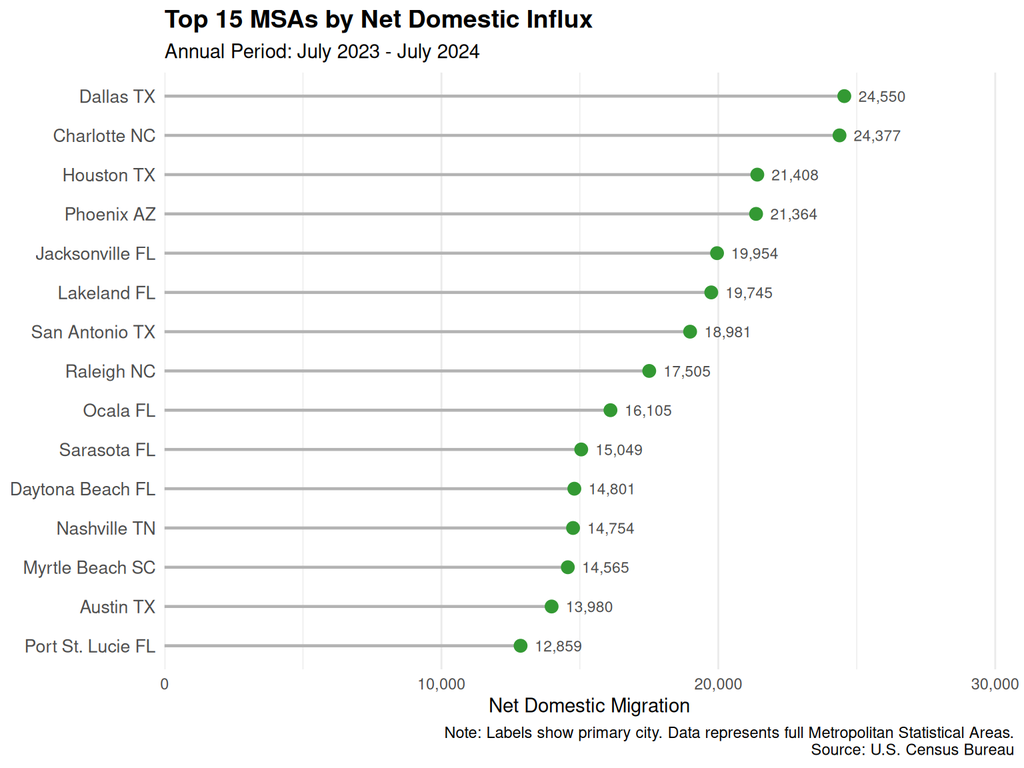

Figure 1

```r
ggplot(top_domestic_influx_cap_names, aes(x = reorder(cleaned_geo_name, domestic_annual_change),
                                          y = domestic_annual_change)) +
  geom_segment(aes(x = reorder(cleaned_geo_name, domestic_annual_change),
                   xend = reorder(cleaned_geo_name, domestic_annual_change),
                   y = 0, yend = domestic_annual_change),
               color = "grey70", linewidth = 0.8) +
  geom_point(color = "#339933", size = 3) +
  geom_text(aes(label = scales::label_comma()(domestic_annual_change)),
            hjust = -0.3, size = 3, color = "grey30") +
  coord_flip() +
  scale_y_continuous(labels = scales::label_comma(), expand = expansion(mult = c(0, 0.25))) +
  labs(
    title = "Top 15 MSAs by Net Domestic Influx",
    subtitle = "Annual Period: July 2023 - July 2024",
    x = NULL, y = "Net Domestic Migration",
    caption = "Note: Labels show primary city. Data represents full Metropolitan Statistical Areas.\nSource: U.S. Census Bureau"
  ) +
  theme_minimal() +
  theme(
    panel.grid.major.y = element_blank(),
    plot.title = element_text(face = "bold", size = 14),
    axis.text.y = element_text(size = 10),
    plot.background = element_rect(fill = "white", color = NA)
  )
```

## 5.2 Identifying Top Metropolitan Areas by Net International Migration (2023-2024)

To complement our domestic migration findings and evaluate global population inflows, we turn to the annual net international migration estimates for the same 2023-2024 period.

Building on the geographic string-cleaning pipeline established in Section 5.1, we extract the top 15 MSAs by international influx. Because generalized regex shortening caused naming collisions for major economic centers sharing state abbreviations – such as reducing both San Francisco and San Jose to a generic “San CA” – we incorporate a targeted `case_when()` override to preserve distinct regional identities for major global gateways.

**Show R Code**

```r
# Step 1: Filter, rank, and clean geographic names for international migration leaders
top_international_influx <- comp_of_pop_change_identifier %>%
  filter(international_annual_change > 0) %>%
  arrange(desc(international_annual_change)) %>%
  head(15) %>%
  mutate(
    shortened_geo_name = str_replace(geographic_area_name,
                                     "^(.*?)[\\s,-].*\\s([a-z]{2})$", "\\1 \\2"),
    cleaned_geo_name = str_to_title(shortened_geo_name) %>%
      str_replace_all("\\b[A-Za-z]{2}\\b", toupper),

    # Resolve regex collisions and standardize primary geographic names
    cleaned_geo_name = case_when(
      str_detect(geographic_area_name, "san francisco") ~ "San Francisco CA",
      str_detect(geographic_area_name, "san jose") ~ "San Jose CA",
      str_detect(geographic_area_name, "new york") ~ "New York NY",
      str_detect(geographic_area_name, "los angeles") ~ "Los Angeles CA",
      str_detect(geographic_area_name, "chicago") ~ "Chicago IL",
      str_detect(geographic_area_name, "washington") ~ "Washington DC",
      str_detect(geographic_area_name, "boston") ~ "Boston MA",
      str_detect(geographic_area_name, "philadelphia") ~ "Philadelphia PA",
      TRUE ~ cleaned_geo_name
    )
  ) %>%
  select(cleaned_geo_name, international_annual_change)

# Step 2: Format and display the results for reporting
top_international_influx %>%
  mutate(
    migration = format(international_annual_change, big.mark = ",",
                       scientific = FALSE)
  ) %>%
  select(MSA = cleaned_geo_name, Net_International_Migration = migration) %>%
  print(n = 15, row.names = FALSE)
```

```
# A tibble: 15 × 2
   MSA              Net_International_Migration
   <chr>            <chr>
 1 New York NY      "287,993"
 2 Miami FL         "213,227"
 3 Los Angeles CA   "130,009"
 4 Houston TX       "128,135"
 5 Dallas TX        "102,702"
 6 Chicago IL       " 96,448"
 7 Washington DC    " 83,844"
 8 Boston MA        " 70,731"
 9 San Francisco CA " 67,708"
10 Orlando FL       " 66,800"
11 Seattle WA       " 63,849"
12 Philadelphia PA  " 52,618"
13 Atlanta GA       " 49,691"
14 Phoenix AZ       " 48,833"
15 San Jose CA      " 44,829"
```

To complement our domestic migration analysis and examine global population flows, we visualize the leading metropolitan destinations for net international migration.

Mirroring the formatting of our domestic migration chart, the lollipop visualization below highlights the major metropolitan gateways attracting the highest volumes of international residents.

**Show R Code**

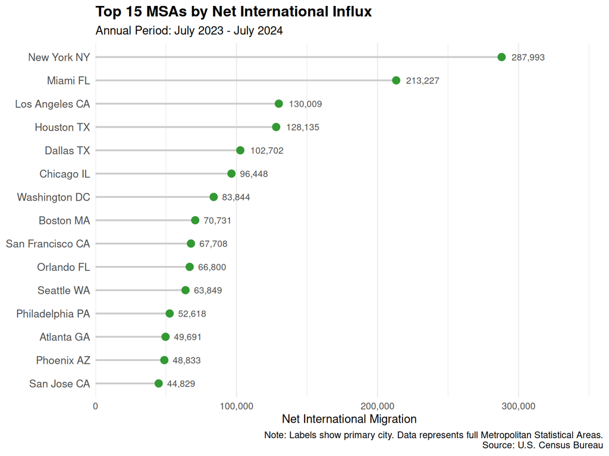

Figure 2

```r
ggplot(top_international_influx, aes(x = reorder(cleaned_geo_name, international_annual_change),
                                     y = international_annual_change)) +
  geom_segment(aes(x = reorder(cleaned_geo_name, international_annual_change),
                   xend = reorder(cleaned_geo_name, international_annual_change),
                   y = 0, yend = international_annual_change),
               color = "grey80", linewidth = 0.8) +
  geom_point(color = "#339933", size = 3) +
  geom_text(aes(label = scales::label_comma()(international_annual_change)),
            hjust = -0.3, size = 3, color = "grey30") +
  coord_flip() +
  scale_y_continuous(labels = scales::label_comma(), expand = expansion(mult = c(0, 0.25))) +
  labs(
    title = "Top 15 MSAs by Net International Influx",
    subtitle = "Annual Period: July 2023 - July 2024",
    x = NULL, y = "Net International Migration",
    caption = "Note: Labels show primary city. Data represents full Metropolitan Statistical Areas.\nSource: U.S. Census Bureau"
  ) +
  theme_minimal() +
  theme(
    panel.grid.major.y = element_blank(),
    plot.title = element_text(face = "bold", size = 14),
    axis.text.y = element_text(size = 10),
    plot.background = element_rect(fill = "white", color = NA)
  )
```

## 5.3 Identifying Top Metropolitan Areas by Net Migration Outflux (2023-2024)

While many metropolitan areas experience population expansion, identifying regions undergoing demographic decline requires calculating total net migration by combining both domestic and international annual components.

Building on the text-cleaning workflows established in previous sections, we apply our standard regular expression pipeline and title-casing transformations. To resolve a new regional naming collision – where both Santa Cruz and Santa Barbara were shortened to “Santa CA” – we extend our conditional `case_when()` logic to ensure distinct, accurate labels for these coastal California regions, alongside other outflux centers like Memphis and New Orleans.

**Show R Code**

```r
# Step 1: Calculate total net migration, filter for negative growth, and clean names
top_net_outflux <- comp_of_pop_change_identifier %>%
  mutate(
    # Calculate total net migration annually
    total_net_migration_annual = domestic_annual_change + international_annual_change
  ) %>%
  # Filter for only negative net migration
  filter(total_net_migration_annual < 0) %>%
  # Arrange negative total migration in ascending order (most negative first)
  arrange(total_net_migration_annual) %>%
  # Show the top 15 MSAs
  head(15) %>%
  mutate(
    # Create shortened geographic area names using regex
    shortened_geo_name = str_replace(geographic_area_name,
                                     "^(.*?)[\\s,-].*\\s([a-z]{2})$", "\\1 \\2"),
    # Capitalize geographic area names
    cleaned_geo_name = str_to_title(shortened_geo_name) %>%
      str_replace_all("\\b[A-Za-z]{2}\\b", toupper),

    # Resolve regional naming collisions and standardize primary geographic names
    cleaned_geo_name = case_when(
      str_detect(geographic_area_name, "santa cruz") ~ "Santa Cruz CA",
      str_detect(geographic_area_name, "santa barbara") ~ "Santa Barbara CA",
      str_detect(geographic_area_name, "memphis") ~ "Memphis TN",
      str_detect(geographic_area_name, "el paso") ~ "El Paso TX",
      str_detect(geographic_area_name, "new orleans") ~ "New Orleans LA",
      TRUE ~ cleaned_geo_name
    )
  ) %>%
  select(
    geo_id,
    cleaned_geo_name,
    domestic_annual_change,
    international_annual_change,
    total_net_migration_annual
  )

# Step 2: Format and print the outflux results
top_net_outflux %>%
  mutate(
    Net_Domestic = format(domestic_annual_change, big.mark = ",",
                          scientific = FALSE),
    Net_International = format(international_annual_change, big.mark = ",",
                               scientific = FALSE),
    Total_Outflux = format(total_net_migration_annual, big.mark = ",",
                           scientific = FALSE)
  ) %>%
  select(
    MSA = cleaned_geo_name,
    Net_Domestic,
    Net_International,
    Total_Outflux
  ) %>%
  print(n = 15, row.names = FALSE)
```

```
# A tibble: 15 × 4
   MSA              Net_Domestic Net_International Total_Outflux
   <chr>            <chr>        <chr>             <chr>
 1 Memphis TN       " -9,674"    "5,641"           "-4,033"
 2 Jackson MS       " -5,574"    "1,928"           "-3,646"
 3 El Paso TX       " -7,355"    "4,472"           "-2,883"
 4 New Orleans LA   "-10,668"    "8,564"           "-2,104"
 5 Salinas CA       " -5,447"    "3,415"           "-2,032"
 6 Fayetteville NC  " -4,028"    "2,395"           "-1,633"
 7 Santa Cruz CA    " -2,801"    "1,226"           "-1,575"
 8 Fairbanks AK     " -1,849"    "  353"           "-1,496"
 9 Kahului HI       " -2,567"    "1,245"           "-1,322"
10 Watertown NY     " -1,703"    "  575"           "-1,128"
11 Santa Barbara CA " -4,612"    "3,487"           "-1,125"
12 Lawton OK        "   -962"    "  156"           "  -806"
13 Shreveport LA    " -1,806"    "1,144"           "  -662"
14 Elkhart IN       " -1,462"    "  917"           "  -545"
15 Napa CA          " -1,155"    "  622"           "  -533"
```

To visualize demographic contraction, the lollipop chart below maps the 15 metropolitan statistical areas experiencing the largest net population outflux. By using a distinct color palette (`firebrick`) for negative growth, the visualization clearly highlights regions where domestic outmigration outpaces international arrivals.

**Show R Code**

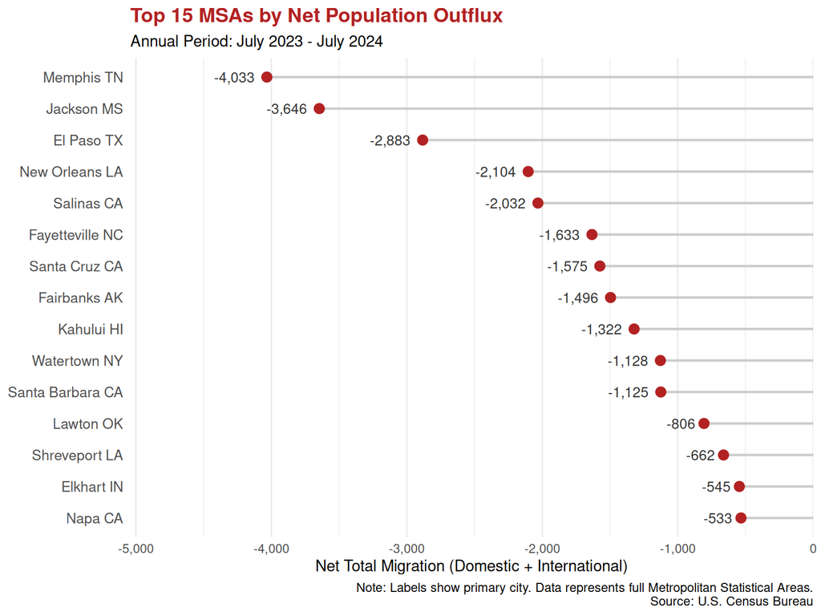

Figure 3

```r
ggplot(top_net_outflux, aes(x = reorder(cleaned_geo_name, -total_net_migration_annual),
                            y = total_net_migration_annual)) +
  geom_segment(aes(x = reorder(cleaned_geo_name, -total_net_migration_annual),
                   xend = reorder(cleaned_geo_name, -total_net_migration_annual),
                   y = 0, yend = total_net_migration_annual),
               color = "grey80", linewidth = 0.8) +
  geom_point(color = "firebrick", size = 3) +
  geom_text(aes(label = scales::label_comma()(total_net_migration_annual)),
            hjust = 1.3, size = 3.5, color = "grey20") +
  coord_flip() +
  scale_y_continuous(labels = scales::label_comma(), expand = expansion(mult = c(0.25, 0))) +
  labs(
    title = "Top 15 MSAs by Net Population Outflux",
    subtitle = "Annual Period: July 2023 - July 2024",
    x = NULL,
    y = "Net Total Migration (Domestic + International)",
    caption = "Note: Labels show primary city. Data represents full Metropolitan Statistical Areas.\nSource: U.S. Census Bureau"
  ) +
  theme_minimal() +
  theme(
    panel.grid.major.y = element_blank(),
    plot.title = element_text(face = "bold", size = 14, color = "firebrick"),
    axis.text.y = element_text(size = 10),
    plot.background = element_rect(fill = "white", color = NA)
  )
```

## 5.4 Deconstructing Population Growth Drivers: Natural Change versus Migration (2023-2024)

To understand the underlying drivers behind overall population growth, we examine how natural population change (births minus deaths) compares against net domestic and international migration.

Applying our established string-cleaning and formatting pipeline – complete with targeted overrides for major metros like New York, Washington, and Las Vegas – we rank the top 15 metropolitan areas by total annual population change. We then reshape the dataset from wide to long format using `pivot_longer()`, preparing the data to evaluate the relative contributions of natural versus migratory growth.

**Show R Code**

```r
# Step 1: Calculate and reshape population change components of change for top growth drivers
top_population_drivers <- comp_of_pop_change_identifier %>%
  # Arranging total annual population change list in descending order
  arrange(desc(total_annual_change)) %>%
  # Showing the top 15 MSAs
  head(15) %>%
  mutate(
    # Creating shortened geographic area names using regex
    shortened_geo_name = str_replace(geographic_area_name,
                                     "^(.*?)[\\s,-].*\\s([a-z]{2})$", "\\1 \\2"),
    # Capitalizing geographic area names
    cleaned_geo_name = str_to_title(shortened_geo_name) %>%
      str_replace_all("\\b[A-Za-z]{2}\\b", toupper),

    # Manually adjusting geographic area names for precision
    cleaned_geo_name = case_when(
      str_detect(geographic_area_name, "new york") ~ "New York NY",
      str_detect(geographic_area_name, "washington") ~ "Washington DC",
      str_detect(geographic_area_name, "charlotte") ~ "Charlotte NC",
      str_detect(geographic_area_name, "chicago") ~ "Chicago IL",
      str_detect(geographic_area_name, "boston") ~ "Boston MA",
      str_detect(geographic_area_name, "las vegas") ~ "Las Vegas NV",
      TRUE ~ cleaned_geo_name
    )
  ) %>%
  # Selecting only pertinent data
  select(
    # First, selecting columns for future joins
    geo_id,
    cleaned_geo_name,
    # Adding columns from original dataframe and altering column names for visualization
    `Natural Change` = natural_annual_change,
    `Domestic Migration` = domestic_annual_change,
    `International Migration` = international_annual_change
  ) %>%
  # Transforming to long format for visualization
  pivot_longer(
    cols = c(-geo_id, -cleaned_geo_name),
    names_to = "Component",
    values_to = "Value"
  )

# Step 2: Preview the first few rows of the pivoted dataframe
head(top_population_drivers)
```

```
# A tibble: 6 × 4
  geo_id cleaned_geo_name Component                 Value
  <chr>  <chr>            <chr>                     <dbl>
1 26420  Houston TX       Natural Change            48866
2 26420  Houston TX       Domestic Migration        21408
3 26420  Houston TX       International Migration  128135
4 35620  New York NY      Natural Change            72316
5 35620  New York NY      Domestic Migration      -146888
6 35620  New York NY      International Migration  287993
```

To visualize how different demographic components combine to drive overall population growth, we construct a stacked horizontal bar chart using our long-format data.

The visualization below contrasts natural change against domestic and international migration across the leading U.S. metropolitan areas.

**Show R Code**

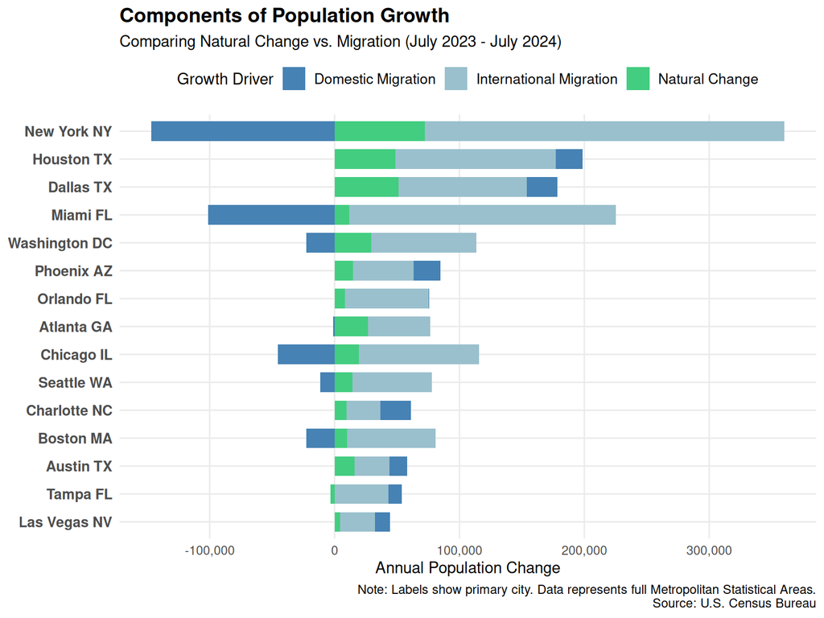

Figure 4

```r
ggplot(top_population_drivers, aes(x = reorder(cleaned_geo_name, Value, sum),
                                   y = Value, fill = Component)) +
  geom_col(width = 0.7) +
  coord_flip() +
  scale_y_continuous(labels = scales::label_comma()) +
  scale_fill_manual(values = c(
    "Domestic Migration" = "steelblue",
    "International Migration" = "lightblue3",
    "Natural Change" = "seagreen3"
  )) +
  labs(
    title = "Components of Population Growth",
    subtitle = "Comparing Natural Change vs. Migration (July 2023 - July 2024)",
    x = NULL,
    y = "Annual Population Change",
    fill = "Growth Driver",
    caption = "Note: Labels show primary city. Data represents full Metropolitan Statistical Areas.\nSource: U.S. Census Bureau"
  ) +
  theme_minimal() +
  theme(
    legend.position = "top",
    panel.grid.minor = element_blank(),
    plot.title = element_text(face = "bold", size = 14),
    axis.text.y = element_text(size = 10, face = "bold"),
    legend.text = element_text(size = 10)
  )
```

## 5.5 Analyzing Migration Patterns by Metropolitan Population Scale (2023-2024)

To determine whether metropolitan scale influences demographic dynamics, we examine whether areas with higher total populations exhibit distinct migration patterns.

We merge our components of change dataset with total population estimates (`total_pop_`  
`2024_cleaned`) to categorize MSAs into structured size tiers – ranging from mega regions (5M+) down to smaller metro areas (<250K). By grouping and summarizing net domestic migration, international migration, and natural change within each tier, we can evaluate how growth drivers shift across city scales. The code below performs this join, applies the size classifications, aggregates the components, and pivots the data into a long format for upcoming visualization.

**Show R Code**

```r
# Step 1: Join population estimates, assign size tiers, and aggregate migration components
pop_size_analysis <- comp_of_pop_change_identifier %>%
  inner_join(total_pop_2024_cleaned %>%
               select(geo_id, total_pop = total_population_estimate),
             by = "geo_id") %>%
  mutate(
    # Creating size tiers based on the 'total_population_estimate'
    city_size_tier = case_when(
      total_pop >= 5000000 ~ "Mega (5M+)",
      total_pop >= 1000000 ~ "Large (1M - 5M)",
      total_pop >= 250000  ~ "Medium (250K - 1M)",
      TRUE                 ~ "Small (<250K)"
    ),
    # Ensuring tiers appear in logical order (largest to smallest)
    city_size_tier = factor(city_size_tier,
                            levels = c("Mega (5M+)", "Large (1M - 5M)",
                                       "Medium (250K - 1M)", "Small (<250K)"))
  ) %>%
  # Grouping by size tier to see the aggregated behavior of each group
  group_by(city_size_tier) %>%
  summarize(
    `Domestic Migration` = sum(domestic_annual_change, na.rm = TRUE),
    `International Migration` = sum(international_annual_change, na.rm = TRUE),
    `Natural Change` = sum(natural_annual_change, na.rm = TRUE),
    .groups = "drop"
  ) %>%
  # Transforming to long format for visualization
  pivot_longer(
    cols = -city_size_tier,
    names_to = "Component",
    values_to = "Value"
  )

# Step 2: Preview the first few rows of the pivoted dataframe
head(pop_size_analysis)
```

```
# A tibble: 6 × 3
  city_size_tier  Component                 Value
  <fct>           <chr>                     <dbl>
1 Mega (5M+)      Domestic Migration      -408052
2 Mega (5M+)      International Migration 1264231
3 Mega (5M+)      Natural Change           327878
4 Large (1M - 5M) Domestic Migration        -2377
5 Large (1M - 5M) International Migration  854486
6 Large (1M - 5M) Natural Change           220265
```

To evaluate how structural demographics scale across different metropolitan sizes, the 100% stacked bar chart below normalizes total annual change into proportional shares.

Using `position = "fill"`, this visualization reveals whether mega-regions rely primarily on international gateways while mid-sized or smaller metro areas are driven by domestic migration or natural growth. This chart clearly illustrates how growth drivers shift across population tiers.

**Show R Code**

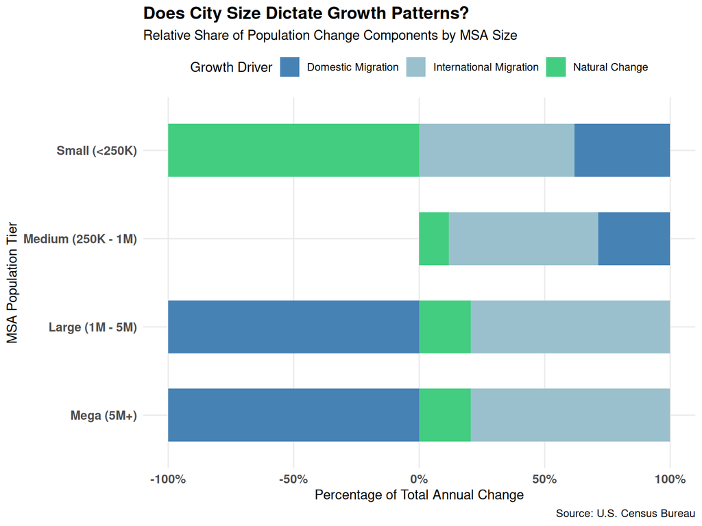

Figure 5

```r
ggplot(pop_size_analysis, aes(x = city_size_tier, y = Value, fill = Component)) +
  geom_col(position = "fill", width = 0.6) +
  coord_flip() +
  scale_y_continuous(labels = scales::label_percent()) +
  scale_fill_manual(values = c(
    "Domestic Migration" = "steelblue",
    "International Migration" = "lightblue3",
    "Natural Change" = "seagreen3"
  )) +
  labs(
    title = "Does City Size Dictate Growth Patterns?",
    subtitle = "Relative Share of Population Change Components by MSA Size",
    x = "MSA Population Tier",
    y = "Percentage of Total Annual Change",
    fill = "Growth Driver",
    caption = "Source: U.S. Census Bureau"
  ) +
  theme_minimal() +
  theme(
    legend.position = "top",
    panel.grid.minor = element_blank(),
    plot.title = element_text(face = "bold", size = 14),
    axis.text = element_text(size = 10, face = "bold")
  )
```

## 5.6 Correlating Migration Patterns with Employment Growth (2023-2024)

To evaluate whether economic opportunity drives population movement, we examine the relationship between local employment growth and net domestic migration across U.S. metropolitan statistical areas.

We merge our Bureau of Labor Statistics (BLS) employment dataset (`bls_employment_data_`  
`2024`) with the components of population change and total population estimates. Using these combined metrics, we calculate the annual percentage change in employment (`job_growth`  
`_pct`) alongside the normalized net domestic migration rate per 1,000 residents (`migration_`  
`rate_per_1k`). The code below performs this multi-source join, computes the normalized indicators, filters out non-finite outliers, and previews the resulting analysis dataset.

**Show R Code**

```r
# Step 1: Join BLS employment, migration, and population data, then compute growth rates
job_migration_correlation <- bls_employment_data_2023_2024 %>%
  # Selecting key BLS columns
  select(geo_id, jul_2023, jul_2024) %>%
  # Joining with migration data
  inner_join(comp_of_pop_change_identifier %>%
               select(geo_id, domestic_annual_change), by = "geo_id") %>%
  # Joining with population data for normalization
  inner_join(total_pop_2024_cleaned %>%
               select(geo_id, total_pop = total_population_estimate,
                      cleaned_geo_name = geographic_area_name), by = "geo_id") %>%
  # Calculating metrics
  mutate(
    job_growth_pct = ((jul_2024 - jul_2023) / jul_2023) * 100,
    migration_rate_per_1k = (domestic_annual_change / total_pop) * 1000
  ) %>%
  # Filtering out potential data outliers
  filter(is.finite(job_growth_pct), is.finite(migration_rate_per_1k))

# Step 2: Preview the first few rows of the migration to job growth dataframe
head(job_migration_correlation)
```

```
# A tibble: 6 × 8
  geo_id jul_2023 jul_2024 domestic_annual_change total_pop cleaned_geo_name
  <chr>     <dbl>    <dbl>                  <dbl>     <dbl> <chr>
1 11500      46.5     46.8                    258    116427 anniston oxford al
2 12220      78.1     78.8                   1400    205355 auburn opelika al
3 13820     566.     569                     2205   1192583 birmingham al
4 19300      90.3     92.4                   6570    261608 daphne fairhope fol…
5 19460      60.2     61.6                    312    159651 decatur al
6 20020      62.6     63.3                   1200    154766 dothan al
# ℹ 2 more variables: job_growth_pct <dbl>, migration_rate_per_1k <dbl>
```

To test the classic economic hypothesis that population movement tracks employment opportunities, we visualize the relationship between local job growth percentages and normalized net domestic migration rates.

The scatter plot below incorporates a linear regression trend line (`geom_smooth`) to capture the broader macro-level correlation across all metropolitan areas. Additionally, by programmatically labeling the top outlier regions via `slice_max()`, the visualization highlights where rapid domestic influx is most strongly tied to local economic expansion.

**Show R Code**

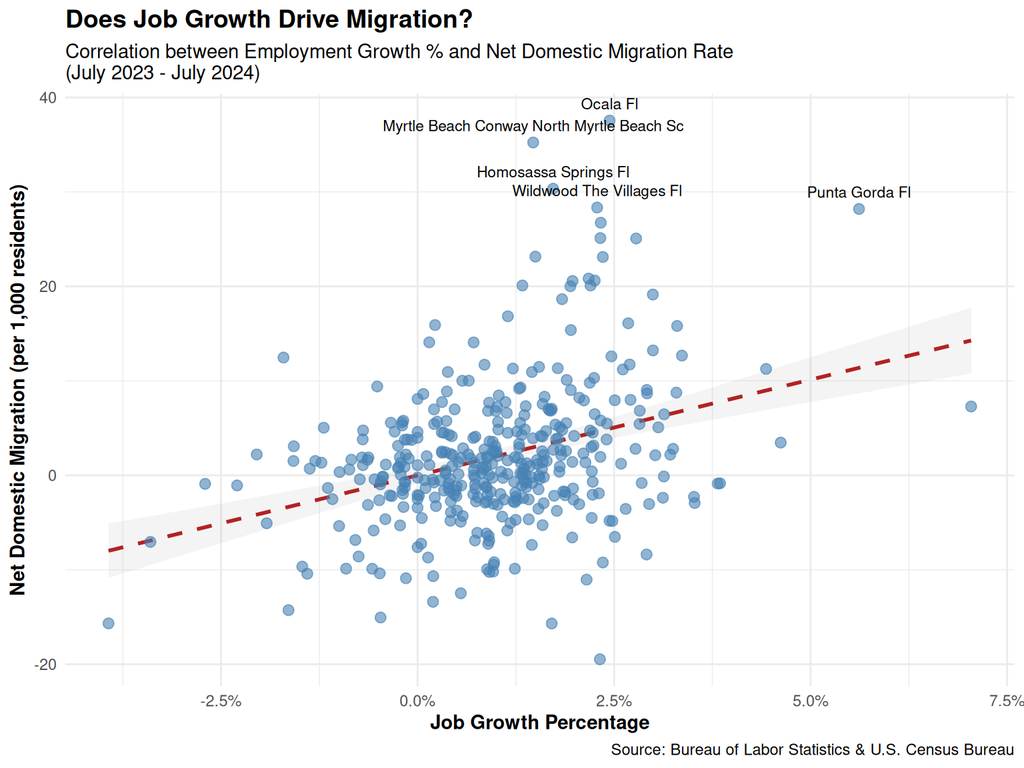

Figure 6

```r
ggplot(job_migration_correlation, aes(x = job_growth_pct, y = migration_rate_per_1k)) +
  # Adding a trend line (Linear Regression)
  geom_smooth(method = "lm", color = "firebrick", linetype = "dashed", se = TRUE, alpha = 0.1) +
  # Adding the points
  geom_point(alpha = 0.6, color = "steelblue", size = 2.5) +
  # Labeling specifically interesting MSAs (Top Growth/Migration)
  geom_text(data = job_migration_correlation %>% slice_max(migration_rate_per_1k, n = 5),
            aes(label = str_to_title(cleaned_geo_name)),
            vjust = -1, size = 3, check_overlap = TRUE) +
  scale_x_continuous(labels = scales::label_percent(scale = 1)) +
  labs(
    title = "Does Job Growth Drive Migration?",
    subtitle = "Correlation between Employment Growth % and Net Domestic Migration Rate\n(July 2023 - July 2024)",
    x = "Job Growth Percentage",
    y = "Net Domestic Migration (per 1,000 residents)",
    caption = "Source: Bureau of Labor Statistics & U.S. Census Bureau"
  ) +
  theme_minimal() +
  theme(
    plot.title = element_text(face = "bold", size = 14),
    axis.title = element_text(face = "bold")
  )
```

To formally evaluate the predictive power of local employment growth on population movement, we fit a simple linear regression model mapping the net domestic migration rate against annual job growth percentages.

While the scatter plot indicates a general positive slope, the resulting $R^2$ value measures the proportion of variance in domestic migration rates that can be explained by local job growth alone. Including these regression statistics provides empirical context to our findings, helping distinguish between regions where economic expansion serves as the primary magnet for residents versus areas driven by lifestyle, housing affordability, or retirement migration trends.

**Show R Code**

```r
# Step 1: Fit the Linear Model
# Formula: Dependent Variable (Migration) ~ Independent Variable (Jobs)
fit <- lm(migration_rate_per_1k ~ job_growth_pct, data = job_migration_correlation)
fit_summary <- summary(fit)

# Step 2: Create a presentation-ready data frame for key model statistics
model_metrics <- data.frame(
  Metric = c("R-Squared ($R^2$)", "Adjusted R-Squared", "F-Statistic", "p-value"),
  Value = c(
    round(fit_summary$r.squared, 4),
    round(fit_summary$adj.r.squared, 4),
    round(fit_summary$fstatistic[1], 2),
    signif(pf(fit_summary$fstatistic[1], fit_summary$fstatistic[2], fit_summary$fstatistic[3],
              lower.tail = FALSE), 3)
  )
)

# Step 3: Display as a polished table
knitr::kable(model_metrics, escape = FALSE, caption = "Linear Model Summary: Net Domestic Migration Rate vs. Employment Growth Percentage")
```

Linear Model Summary: Net Domestic Migration Rate vs. Employment Growth Percentage

| Metric | Value |
| --- | --- |
| R-Squared ($R^2$) | 0.1148 |
| Adjusted R-Squared | 0.1125 |
| F-Statistic | 49.9300 |
| p-value | 0.0000 |

The regression metrics reveal a nuanced relationship between local employment growth and net domestic migration.

The $R^2$ value of $0.1148$ indicates that approximately **11.5% of the variance** in net domestic migration rates across U.S. metropolitan areas can be explained by annual job growth percentages alone. While employment opportunity is a tangible driver of relocation, this moderate coefficient demonstrates that a substantial portion of domestic migration is governed by other unmodeled forces – such as housing affordability, cost of living, climate preferences, retirement shifts, and post-pandemic remote work flexibility.

However, despite the modest proportion of explained variance, the overall model is **statistically** **highly significant**, supported by an F-statistic of $49.93$ and a p-value effectively near zero ($p$ $< 0.001$). This confirms that the positive relationship between job growth and domestic influx is robust and highly unlikely to be the results of random chance, validating job creation as a reliable baseline predictor even if lifestyle and economic trade-offs ultimately dictate where residents choose to move.

## 5.7 Evaluating the Impact of Cost of Living on Domestic Migration (2023-2024)

To evaluate whether regional cost burdens influence population shifts, we incorporate the Bureau of Economic Analysis’ Regional Price Parities (RPP) data.

We isolate the 2023 RPP estimates from our cleaned BEA dataset and perform an inner join with our existing `job_migration_correlation` framework. This aligns each metropolitan statistical area’s local price level – where 100 represents the national average – with its corresponding migration and employment metrics.

**Show R Code**

```r
rpp_2023 <- msa_rpp_cleaned %>%
  filter(year == 2023) %>%
  select(geo_id, rpp_2023 = rpp)

rpp_migration_analysis <- job_migration_correlation %>%
  inner_join(rpp_2023, by = "geo_id")
```

To test the hypothesis that high living costs drive residents away, we construct a scatter plot mapping the 2023 RPP index against normalized net domestic migration rates. A vertical reference line at $RPP =$ $100$ clearly demarcates affordable regions from high-cost-of-living metropolitan areas, while a linear regression trend line and programmatic labeling highlight how migration patterns interact with local price tags.

**Show R Code**

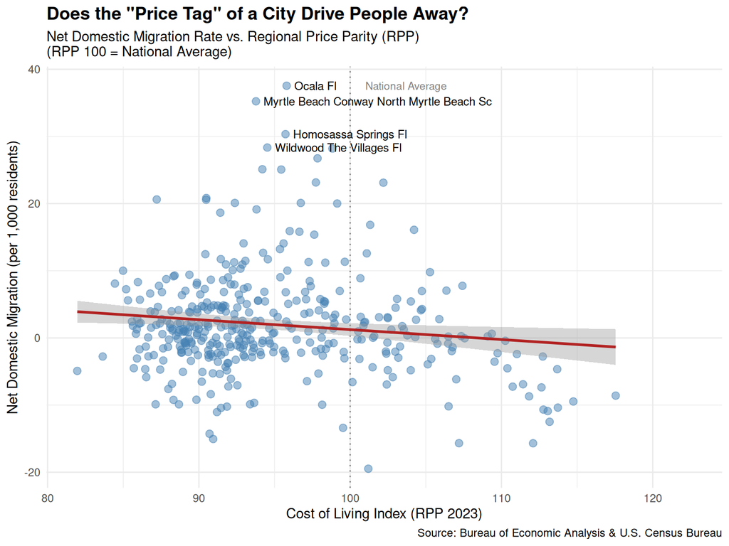

Figure 7

```r
ggplot(rpp_migration_analysis, aes(x = rpp_2023, y = migration_rate_per_1k)) +
  # Reference line for the national average cost of living
  geom_vline(xintercept = 100, linetype = "dotted", color = "grey50") +
  annotate("text", x = 101, y = max(rpp_migration_analysis$migration_rate_per_1k),
           label = "National Average", hjust = 0, size = 3, color = "grey50") +
  # The points and trend line
  geom_point(alpha = 0.5, color = "steelblue", size = 2.5) +
  geom_smooth(method = "lm", color = "firebrick", se = TRUE) +
  # Labels for high-impact cities
  geom_text(data = rpp_migration_analysis %>% slice_max(migration_rate_per_1k, n = 5),
            aes(label = str_to_title(cleaned_geo_name)), hjust = 0, nudge_x = 0.5, size = 3.2,
            check_overlap = TRUE) +
  # Expanding the X-axis limit slightly so the right-side labels don't get cut off
  expand_limits(x = max(rpp_migration_analysis$rpp_2023) + 5) +
  labs(
    title = "Does the \"Price Tag\" of a City Drive People Away?",
    subtitle = "Net Domestic Migration Rate vs. Regional Price Parity (RPP)\n(RPP 100 = National Average)",
    x = "Cost of Living Index (RPP 2023)",
    y = "Net Domestic Migration (per 1,000 residents)",
    caption = "Source: Bureau of Economic Analysis & U.S. Census Bureau"
  ) +
  theme_minimal() +
  theme(plot.title = element_text(face = "bold", size = 14))
```

To isolate how regional cost pressures and employment opportunities jointly influence population movement, we fit a multiple regression model. By combining job growth percentages and the 2023 Regional Price Parity (RPP) index into a single equation, we can evaluate the independent effect of each factor while controlling for the other.

The code chunk below executes both the model fitting and the standard summary output:

**Show R Code**

```r
# Step 1: Fit the multiple regression model
multi_fit <- lm(migration_rate_per_1k ~ job_growth_pct + rpp_2023, data = rpp_migration_analysis)

# Step 2: Extract coefficients matrix from the summary object
multi_summary <- summary(multi_fit)
coef_df <- as.data.frame(multi_summary$coefficients)

# Step 3: Clean and format columns for presentation
coef_table <- coef_df %>%
  mutate(
    Variable = c("Intercept", "Job Growth (%)", "Cost of Living (RPP 2023)"),
    `Standardized Estimate ($\\beta$)` = round(Estimate, 4),
    `Std. Error` = round(`Std. Error`, 4),
    `t value` = round(`t value`, 2),
    `p-value` = ifelse(`Pr(>|t|)` < 0.001, "< 0.001", round(`Pr(>|t|)`, 4))
  ) %>%
  select(Variable, `Standardized Estimate ($\\beta$)`, `Std. Error`, `t value`, `p-value`)

# Step 4: Render the formatted table
knitr::kable(
  coef_table,
  escape = FALSE,
  caption = sprintf("Multiple Regression Results | **Total R-Squared: %.4f**", summary(multi_fit)$r.squared)
)
```

Multiple Regression Results | **Total R-Squared: 0.1351**

|  | Variable | Standardized Estimate ($\beta$) | Std. Error | t value | p-value |
| --- | --- | --- | --- | --- | --- |
| (Intercept) | Intercept | 15.1602 | 5.0754 | 2.99 | 0.003 |
| job_growth_pct | Job Growth (%) | 2.0561 | 0.2843 | 7.23 | < 0.001 |
| rpp_2023 | Cost of Living (RPP 2023) | -0.1604 | 0.0534 | -3.00 | 0.0029 |

The regression summary reveals critical insights into the dual drivers of domestic relocation:

- **Job Growth Percentage ($\beta = 2.06, p < 0.001$)**: Holding cost of living constant, every 1% increase in local employment growth is associated with an increase of approximately 2.06 net domestic migrants per 1,000 residents. This underscores that economic expansion remains a powerful magnet for incoming population.
- **Regional Price Parity ($\beta = -0.16, p < 0.01$)**: Controlling for employment growth, higher living costs exert a statistically significant negative pull on domestic migration. For every 1-point increase in the RPP index, the net domestic migration rate decreases by about 0.16 per 1,000 residents, confirming that high-cost-of-living penalties deter prospective movers.
- **Overall Model Fit ($R^2 = 0.1351$)**: Integrating both employment growth and cost of living lifts the adjusted $R^2$ to $0.1306$ (with an F-statistic of $29.99$, $p < 0.001$). While unmeasured lifestyle and geographic factors still account for the majority of migration variance, the model proves that both economic opportunity and affordability play statistically robust, competing roles in shaping U.S. metropolitan population flows.

## 5.8 Evaluating the Relationship Between Regional GDP Growth and Population Mobility (2022-2023)

To incorporate broader economic output into our analytical framework, we isolate metropolitan Gross Domestic Product (GDP) figures from the Bureau of Economic Analysis (BEA) for 2022 and 2023.

After pivoting the data to compute annual percentage growth, we merge these metrics directly into our master dataset to evaluate whether output expansion acts as a distinct driver of population mobility beyond employment counts and cost of living alone.

**Show R Code**

```r
# Step 1: Calculate annual GDP growth percentage from 2022 to 2023
gdp_growth <- msa_gdp_geo_area_names %>%
  filter(year %in% c(2022, 2023)) %>%
  pivot_wider(
    names_from = year,
    names_prefix = "gdp_",
    values_from = total_msa_gdp
  ) %>%
  mutate(gdp_growth_pct = ((gdp_2023 - gdp_2022) / gdp_2022) * 100) %>%
  select(geo_id, gdp_2023, gdp_growth_pct)

# Step 2: Merge GDP metrics into the master analysis data frame
economic_migration_master <- rpp_migration_analysis %>%
  inner_join(gdp_growth, by = "geo_id")
```

The scatter plot below maps these GDP growth percentages against net domestic migration rates.

By incorporating a linear regression trend line alongside programmatic labels for top economic performers (`slice_max()`), the visualization highlights how aggregate expansion aligns with population shifts across metropolitan areas.

**Show R Code**

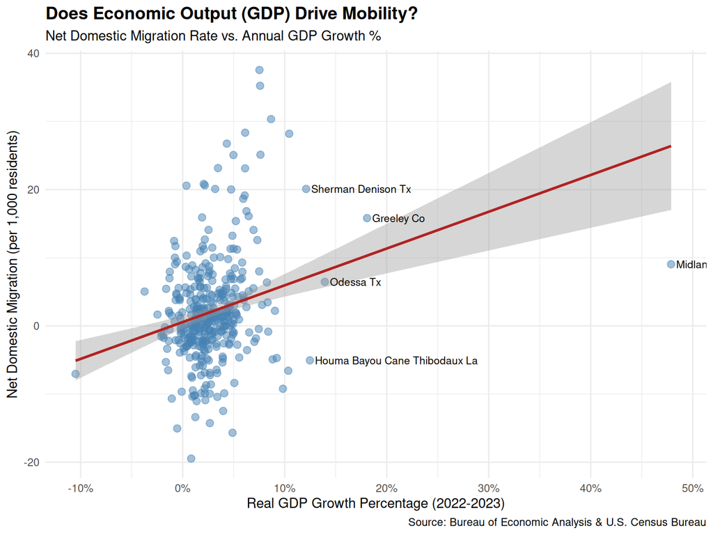

Figure 8

```r
ggplot(economic_migration_master, aes(x = gdp_growth_pct, y = migration_rate_per_1k)) +
  geom_point(alpha = 0.5, color = "steelblue", size = 2.5) +
  geom_smooth(method = "lm", color = "firebrick", se = TRUE) +

  # Labels for high GDP growth cities
  geom_text(data = economic_migration_master %>% slice_max(gdp_growth_pct, n = 5),
            aes(label = str_to_title(cleaned_geo_name)),
            hjust = 0, nudge_x = 0.5, size = 3, check_overlap = TRUE) +
  scale_x_continuous(labels = scales::label_percent(scale = 1)) +
  labs(
    title = "Does Economic Output (GDP) Drive Mobility?",
    subtitle = "Net Domestic Migration Rate vs. Annual GDP Growth %",
    x = "Real GDP Growth Percentage (2022-2023)",
    y = "Net Domestic Migration (per 1,000 residents)",
    caption = "Source: Bureau of Economic Analysis & U.S. Census Bureau"
  ) +
  theme_minimal() +
  theme(plot.title = element_text(face = "bold", size = 14))
```

To determine whether broader macroeconomic output expansion provides additional explanatory power beyond employment counts and cost of living alone, we fit an expanded multiple regression model. By combining real GDP growth percentages with job growth and the RPP index, we can isolate the independent effect of economic productivity on net domestic migration rates.

The code chunk below fits both the unstandardized and standardized versions of the expanded model and renders a publication-ready coefficient table:

**Show R Code**

```r
# Step 1: Fit the final unstandardized and standardized models
final_econ_model <- lm(migration_rate_per_1k ~ job_growth_pct + rpp_2023 + gdp_growth_pct,
                       data = economic_migration_master)

std_final_econ_model <- lm(scale(migration_rate_per_1k) ~ scale(job_growth_pct) + scale(rpp_2023) +
                             scale(gdp_growth_pct),
                           data = economic_migration_master)

# Step 2: Build presentation data frame for standardized coefficients
std_final_summary <- summary(std_final_econ_model)

final_coef_df <- as.data.frame(std_final_summary$coefficients)

final_table <- final_coef_df %>%
  mutate(
    Variable = c("Intercept", "Job Growth (%)", "Cost of Living (RPP)", "GDP Growth (%)"),
    `Standardized Estimate ($\\beta$)` = round(Estimate, 4),
    `Std. Error` = round(`Std. Error`, 4),
    `t value` = round(`t value`, 2),
    `p-value` = ifelse(`Pr(>|t|)` < 0.001, "< 0.001", round(`Pr(>|t|)`, 4))
  ) %>%
  select(Variable, `Standardized Estimate ($\\beta$)`, `Std. Error`, `t value`, `p-value`)

# Step 3: Render table with overall R-squared in caption
knitr::kable(
  final_table,
  escape = FALSE,
  caption = sprintf("Expanded Standardized Regression Results | **Total R-Squared: %.4f**",
                    summary(final_econ_model)$r.squared)
)
```

Expanded Standardized Regression Results | **Total R-Squared: 0.1493**

|  | Variable | Standardized Estimate ($\beta$) | Std. Error | t value | p-value |
| --- | --- | --- | --- | --- | --- |
| (Intercept) | Intercept | 0.0032 | 0.0478 | 0.07 | 0.9463 |
| scale(job_growth_pct) | Job Growth (%) | 0.2786 | 0.0500 | 5.57 | < 0.001 |
| scale(rpp_2023) | Cost of Living (RPP) | -0.1336 | 0.0482 | -2.77 | 0.0058 |
| scale(gdp_growth_pct) | GDP Growth (%) | 0.1732 | 0.0502 | 3.45 | < 0.001 |

The expanded regression results provide a more comprehensive view of the macroeconomic factors influencing population mobility:

- **Overall Model Fit ($R^2$)**: Incorporating GDP growth increases the total explanatory power of the model to $14.93\% (R^2 = 0.1493)$, demonstrating that aggregate regional output captures unique dimensions of economic vitality that employment counts alone do not fully reflect.
- **Job Growth Percentage ($\beta \approx 0.2786, p < 0.001$)**: Holding cost of living and GDP growth constant, employment expansion remains the strongest positive catalyst for domestic migration.
- **GDP Growth Percentage ($\beta \approx 0.1732, p < 0.001$)**: Real GDP growth serves as a powerful secondary pull factor, showing that fast-growing regional economies independently attract new residents even after accounting for immediate job creation and price levels.
- **Cost of Living ($\beta \approx -0.1336, p = 0.0058$)**: High price parities retain a statistically significant dampening effect, confirming that cost burdens continue to exert downward pressure on domestic influx.

## 5.9 Demographic Drivers of Population Mobility

### 5.9.1 Analyzing Domestic Migration by Age Cohort

To determine whether specific demographic cohorts drive the migration trends observed in leading metropolitan areas, we examine age-specific mobility data from the U.S. Census Bureau American Community Survey (ACS).

To map out the exact variables needed for our analysis, we cross-referenced our data against the `ACSST1Y2024.S0701-Column-Metadata.csv` file included in the **S0701: Geographic Mobility by** **Selected Characteristics in the United States** package downloaded from `data.census.`  
`gov`. This metadata documentation allowed us to precisely identify and decode columns corresponding to individuals moving from a different county within the same state (`S0701_C03_*`) and from a different state (`S0701_C04_*`) across various age brackets.

Using these mapped columns across our top 15 population growth MSAs, we aggregate domestic movers into three distinct life-stage cohorts:

- **Young Professionals (18-44)**: Combining ages 18 to 44 to capture early-career relocation and higher-education migration.
- **Established Workforce (45-64)**: Covering mid-career professionals and families.
- **Retirees (65+)**: Tracking older populations moving into retirement destinations.

Using our established geographic name cleaning pipeline – applying standardized regex patterns alongside custom overrides for naming collisions – we format the metropolitan labels for presentation. The code below computes cohort percentages and pivots the data into a long format for upcoming comparative analysis.

**Show R Code**

```r
age_mobility <- geo_mobility_2024_cleaned %>%
  # Focus on the previous Top 15 MSAs by Total Annual Population Change
  filter(geo_id %in% top_population_drivers$geo_id) %>%
  mutate(
    # Use 'coalesce()' to treat missing data as zero so the match doesn't break
    across(starts_with("S0701_"), ~coalesce(., 0)),

    # --- Age group demographics from "Different County/Same State" and "Different State" ---

    # The "Young Professionals" age group (18-44)
    `Young Professionals (18-44)` = (S0701_C03_004E + S0701_C04_004E) +   # 18-24
                                    (S0701_C03_005E + S0701_C04_005E) +   # 25-34
                                    (S0701_C03_006E + S0701_C04_006E),    # 35-44

    # The "Established Workforce" (45-64)
    `Established Workforce (45-64)` = (S0701_C03_007E + S0701_C04_007E) +   # 45-54
                                      (S0701_C03_008E + S0701_C04_008E),    # 55-64

    # The "Retirees" (65+)
    `Retirees (65+)` = (S0701_C03_009E + S0701_C04_009E) +   # 65-74
                       (S0701_C03_010E + S0701_C04_010E)     # 75+
  ) %>%
  # Clean names using our standardized geographic cleaning pipeline
  mutate(
    shortened_geo_name = str_replace(geographic_area_name,
                                     "^(.*?)[\\s,-].*\\s([a-z]{2})$", "\\1 \\2"),
    cleaned_geo_name = str_to_title(shortened_geo_name) %>%
      str_replace_all("\\b[A-Za-z]{2}\\b", toupper),
    cleaned_geo_name = case_when(
      str_detect(geographic_area_name, "boston") ~ "Boston MA",
      str_detect(geographic_area_name, "charlotte") ~ "Charlotte NC",
      str_detect(geographic_area_name, "chicago") ~ "Chicago IL",
      str_detect(geographic_area_name, "vegas") ~ "Las Vegas NV",
      str_detect(geographic_area_name, "york") ~ "New York NY",
      str_detect(geographic_area_name, "washington") ~ "Washington DC",
      TRUE ~ cleaned_geo_name
    )
  ) %>%
  select(
    cleaned_geo_name,
    `Young Professionals (18-44)`,
    `Established Workforce (45-64)`,
    `Retirees (65+)`
  ) %>%
  pivot_longer(
    cols = -cleaned_geo_name,
    names_to = "Cohort",
    # To allow the 'scales' package 'label_percent()' function to convert counts to percentages
    values_to = "Count"
  )
```

To visualize the life cycle breakdown of incoming domestic migrants, we construct a horizontal stacked bar chart displaying the proportional share of each age cohort across our top-performing metropolitan statistical areas.

Using a customized green color palette to represent life-stage progression – from young professionals to retirees – this visualization highlights which demographic groups form the core of incoming population mobility in high-growth regions. This chart clearly exposes whether a region’s influx is driven primarily by early-career job seekers or older retirement populations

**Show R Code**

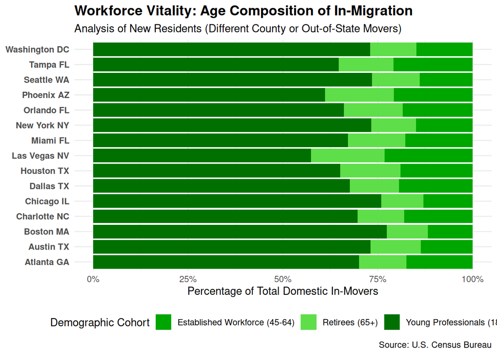

Figure 9

```r
ggplot(age_mobility, aes(x = cleaned_geo_name, y = Count, fill = Cohort)) +
  geom_col(position = "fill") +
  coord_flip() +
  scale_y_continuous(labels = scales::label_percent()) +
  scale_fill_manual(values = c(
    "Young Professionals (18-44)" = "#007100",
    "Established Workforce (45-64)" = "#00A600",
    "Retirees (65+)" = "#5EDE49"
  )) +
  labs(
    title = "Workforce Vitality: Age Composition of In-Migration",
    subtitle = "Analysis of New Residents (Different County or Out-of-State Movers)",
    x = NULL,
    y = "Percentage of Total Domestic In-Movers",
    fill = "Demographic Cohort",
    caption = "Source: U.S. Census Bureau"
  ) +
  theme_minimal() +
  theme(
    legend.position = "bottom",
    plot.title = element_text(face = "bold", size = 14),
    axis.text.y = element_text(face = "bold"),
    plot.background = element_rect(fill = "white", color = NA)
  )
```

### 5.9.2 Analyzing Domestic Migration by Income Bracket

To complement our lifecycle findings, we next investigate the financial distribution of incoming domestic migrants across our top 15 population growth metropolitan statistical areas. Utilizing income bracket metadata from the same ACS S0701 table, we aggregate individual earnings into three broader economic tiers: Entry Level (<$35k), Middle Class ($35k-$75k), and High Earners ($75k).

We employ `coalesce()` to ensure missing sub-category values are safely treated as zero, preventing disruptions during our summation steps. Combined with our standardized geographic name cleaning pipeline, the code chunk below processes, structures, and pivots the income data into a tidy format ready for visualization.

**Show R Code**

```r
# Extract income brackets for in-migrants across top MSAs
income_mobility <- geo_mobility_2024_cleaned %>%
  # Focus on the Top 15 MSAs by Total Annual Population Change
  filter(geo_id %in% top_population_drivers$geo_id) %>%

  mutate(
    # Use 'coalesce()' to treat missing data as zero so the match doesn't break
    across(starts_with("S0701_"), ~coalesce(., 0)),

    # Calculate the sums of the income bracket demographics migrating from "Different County/Same State"
    # and "Different State"
    `Entry Level (<$35k)` = (S0701_C03_040E + S0701_C04_040E) +
                            (S0701_C03_041E + S0701_C04_041E) +
                            (S0701_C03_042E + S0701_C04_042E) +
                            (S0701_C03_043E + S0701_C04_043E),

    `Middle Class ($35k-$75k)` = (S0701_C03_044E + S0701_C04_044E) +
                                 (S0701_C03_045E + S0701_C04_045E) +
                                 (S0701_C03_046E + S0701_C04_046E),

    `High Earners ($75k+)` = (S0701_C03_047E + S0701_C04_047E),

    market_status = "Growth Market (Influx)"
  ) %>%
  # Clean names using our standardized geographic cleaning pipeline
  mutate(
    shortened_geo_name = str_replace(geographic_area_name,
                                     "^(.*?)[\\s,-].*\\s([a-z]{2})$", "\\1 \\2"),
    cleaned_geo_name = str_to_title(shortened_geo_name) %>%
      str_replace_all("\\b[A-Za-z]{2}\\b", toupper),
    cleaned_geo_name = case_when(
      str_detect(geographic_area_name, "boston") ~ "Boston MA",
      str_detect(geographic_area_name, "charlotte") ~ "Charlotte NC",
      str_detect(geographic_area_name, "chicago") ~ "Chicago IL",
      str_detect(geographic_area_name, "vegas") ~ "Las Vegas NV",
      str_detect(geographic_area_name, "york") ~ "New York",
      str_detect(geographic_area_name, "washington") ~ "Washington DC",
      TRUE ~ cleaned_geo_name
    )
  ) %>%
  select(
    cleaned_geo_name,
    market_status,
    `Entry Level (<$35k)`,
    `Middle Class ($35k-$75k)`,
    `High Earners ($75k+)`
  ) %>%
  pivot_longer(
    cols = -c(cleaned_geo_name, market_status),
    names_to = "Income_Bracket",
    values_to = "Count"
  )
```

To illustrate the financial profile of incoming populations, we construct a normalized 100% stacked bar chart mapping the income distribution of inter-county and interstate movers across our top 15 growth metropolitan areas.

Using `position = "fill"` alongside a cohesive green gradiant palette, this visualization highlights whether high-growth regions attract predominantly entry-level earners, middle-class professionals, or high-income brackets.

**Show R Code**

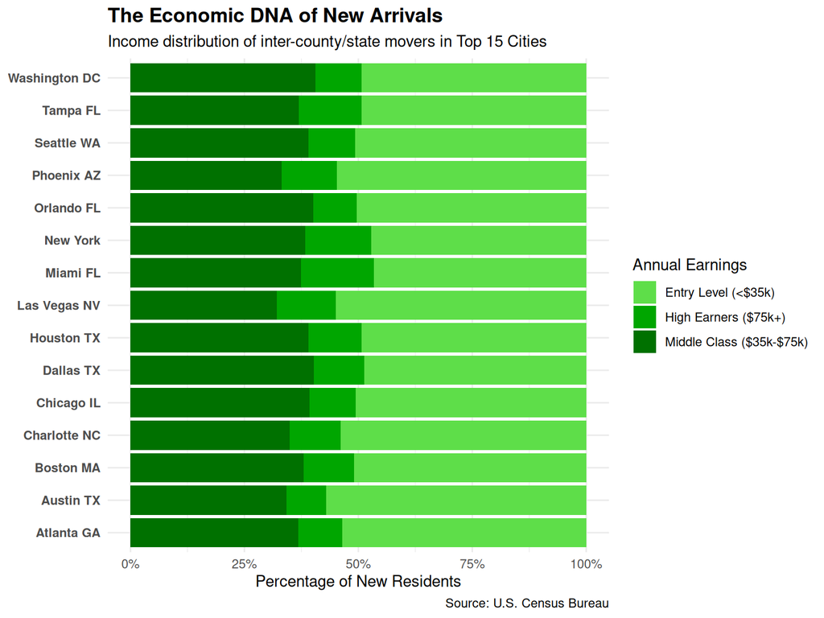

Figure 10

```r
ggplot(income_mobility, aes(x = cleaned_geo_name, y = Count, fill = Income_Bracket)) +
  geom_col(position = "fill") +
  coord_flip() +
  scale_y_continuous(labels = scales::label_percent()) +
  scale_fill_manual(values = c("#5ede49", "#00a600", "#007100")) +
  labs(
    title = "The Economic DNA of New Arrivals",
    subtitle = "Income distribution of inter-county/state movers in Top 15 Cities",
    x = NULL, y = "Percentage of New Residents",
    fill = "Annual Earnings",
    caption = "Source: U.S. Census Bureau"
  ) +
  theme_minimal() +
  theme(
    plot.title = element_text(face = "bold", size = 14),
    axis.text.y = element_text(face = "bold"),
    plot.background = element_rect(fill = "white", color = NA)
  )
```

### 5.9.3 Assessing the Mover Wealth Gap: Gentrification vs. Opportunity

To understand whether leading metropolitan areas are experiencing economic upgrading driven by wealthy newcomers or attracting broader entry-level talent, we construct a “wealth gap” metric. By comparing the median income of incoming movers (averaging inter-county and interstate streams) against the baseline median income of the total metropolitan population, we can identify markets experiencing significant gentrification pressures versus those offering broad-based economic accessiblity.

The code chunk below isolates the median income variables (`S0701_C01_048E` for total population and `S0701_C03_048E` / `S0701_C04_048E` for movers), computes the income differential, applies our standardized geographic cleaning pipeline, and sorts the top 15 MSAs by descending wealth gap magnitude.

**Show R Code**

```r
wealth_gap_data <- geo_mobility_2024_cleaned %>%
  filter(geo_id %in% top_population_drivers$geo_id) %>%
  mutate(
    # Median income for total population
    median_income_total = S0701_C01_048E,
    # Proxy for mover median (average of inter-county and interstate)
    median_income_movers = (S0701_C03_048E + S0701_C04_048E) / 2,
    # The gap
    wealth_gap = median_income_movers - median_income_total
  ) %>%
  # Clean geographic names using our standardized geographic cleaning pipeline
  mutate(
    shortened_geo_name = str_replace(geographic_area_name,
                                     "^(.*?)[\\s,-].*\\s([a-z]{2})$", "\\1 \\2"),
    cleaned_geo_name = str_to_title(shortened_geo_name) %>%
      str_replace_all("\\b[A-Za-z]{2}\\b", toupper),
    cleaned_geo_name = case_when(
      str_detect(geographic_area_name, "boston") ~ "Boston MA",
      str_detect(geographic_area_name, "charlotte") ~ "Charlotte NC",
      str_detect(geographic_area_name, "chicago") ~ "Chicago IL",
      str_detect(geographic_area_name, "vegas") ~ "Las Vegas NV",
      str_detect(geographic_area_name, "york") ~ "New York NY",
      str_detect(geographic_area_name, "washington") ~ "Washington DC",
      TRUE ~ cleaned_geo_name
    )
  ) %>%
  select(
    geo_id,
    cleaned_geo_name,
    median_income_total,
    median_income_movers,
    wealth_gap
  ) %>%
  arrange(desc(wealth_gap))
```

To visualize the economic divergence between incoming populations and established residents, we construct a diverging bar chart mapping the wealth gap across our top 15 growth metropolitan statistical areas.

By distinguishing markets where incoming movers outearn baseline residents (green) from those where newcomers earn less (red), this visualization clearly highlights which regions are experiencing economic upgrading and gentrification pressures versus those absorbing broader entry-level talent. This chart provides a stark look at the financial stratification of population mobility.

**Show R Code**

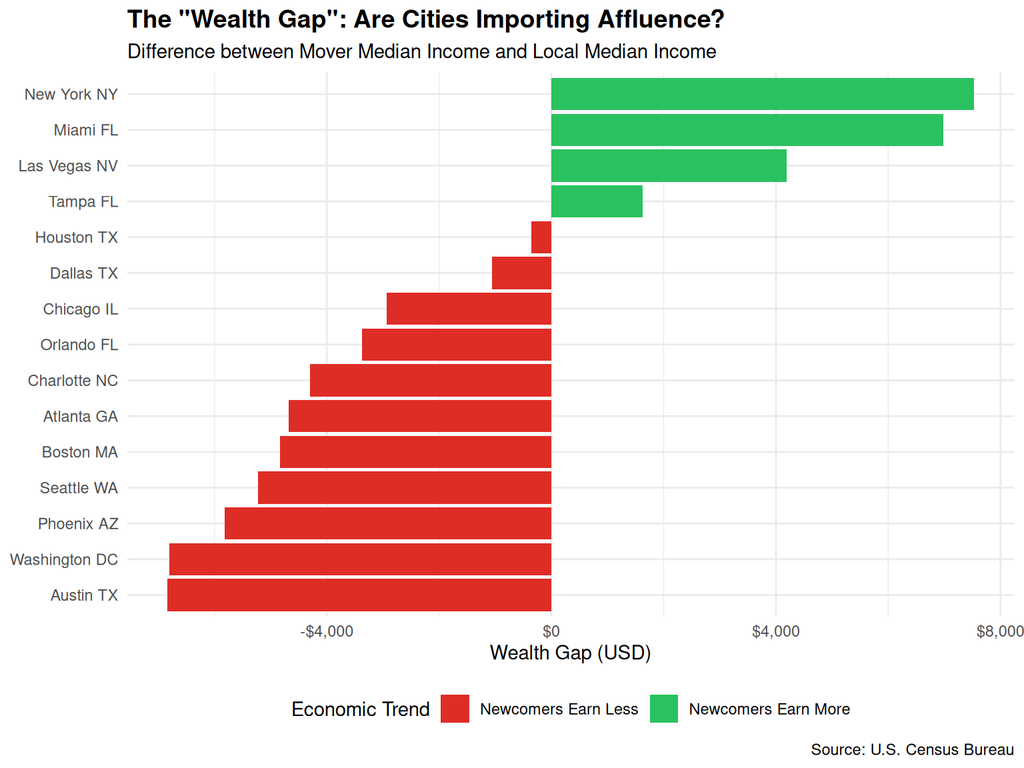

Figure 11

```r
ggplot(wealth_gap_data, aes(x = reorder(cleaned_geo_name, wealth_gap),
                            y = wealth_gap, fill = wealth_gap > 0)) +
  geom_col() +
  coord_flip() +
  scale_fill_manual(values = c("TRUE" = "#2ac25f", "FALSE" = "#de2d26"),
                    labels = c("Newcomers Earn Less", "Newcomers Earn More")) +
  scale_y_continuous(labels = scales::label_dollar()) +
  labs(
    title = "The \"Wealth Gap\": Are Cities Importing Affluence?",
    subtitle = "Difference between Mover Median Income and Local Median Income",
    x = NULL, y = "Wealth Gap (USD)",
    fill = "Economic Trend",
    caption = "Source: U.S. Census Bureau"
  ) +
  theme_minimal() +
  theme(
    legend.position = "bottom",
    plot.title = element_text(face = "bold", size = 14),
    plot.background = element_rect(fill = "white", color = NA)
  )
```

## 5.10 Market Heat Map: Growth Versus Risk Comparison

To contrast the demographic and economic characteristics of booming metropolitan areas against regions experiencing population decline, we evaluate the top 15 risk markets defined by net domestic outflux (`top_net_outflux`). Using the same ACS S0701 income metadata structure, we extract and aggregate earnings brackets for incoming movers in these outflux regions.

Applying `coalesce()` to handle missing values and utilizing our standardized geographic cleaning pipeline – complete with tailored custom overrides for unique market names – the code chunk below processes and tidies the risk market income data so it can be directly compared against our growth market findings.

**Show R Code**

```r
risk_income_mobility <- geo_mobility_2024_cleaned %>%
  filter(geo_id %in% top_net_outflux$geo_id) %>%
  mutate(
    # Use 'coalesce()' to handle any missing data in smaller markets
    across(starts_with("S0701_"), ~coalesce(., 0)),

    `Entry Level (<$35k)` = (S0701_C03_040E + S0701_C04_040E) +
                            (S0701_C03_041E + S0701_C04_041E) +
                            (S0701_C03_042E + S0701_C04_042E) +
                            (S0701_C03_043E + S0701_C04_043E),

    `Middle Class ($35k-$75k)` = (S0701_C03_044E + S0701_C04_044E) +
                                 (S0701_C03_045E + S0701_C04_045E) +
                                 (S0701_C03_046E + S0701_C04_046E),

    `High Earners ($75k+)` = (S0701_C03_047E + S0701_C04_047E),

    # Label this group as "Risk" for comparison
    market_status = "Risk Market (Outflux)"
  ) %>%
  # Clean names using our standardized geographic cleaning pipeline
  mutate(
    shortened_geo_name = str_replace(geographic_area_name,
                                     "^(.*?)[\\s,-].*\\s([a-z]{2})$", "\\1 \\2"),
    cleaned_geo_name = str_to_title(shortened_geo_name) %>%
      str_replace_all("\\b[A-Za-z]{2}\\b", toupper),
    cleaned_geo_name = case_when(
      str_detect(geographic_area_name, "elkhart") ~ "Elkhart-Goshen IN",
      str_detect(geographic_area_name, "paso") ~ "El Paso TX",
      str_detect(geographic_area_name, "memphis") ~ "Memphis TN",
      str_detect(geographic_area_name, "orleans") ~ "New Orleans LA",
      str_detect(geographic_area_name, "cruz") ~ "Santa Cruz CA",
      str_detect(geographic_area_name, "barbara") ~ "Santa Barbara CA",
      TRUE ~ cleaned_geo_name
    )
  ) %>%
  select(
    cleaned_geo_name,
    market_status,
    `Entry Level (<$35k)`,
    `Middle Class ($35k-$75k)`,
    `High Earners ($75k+)`
  ) %>%
  pivot_longer(
    cols = -c(cleaned_geo_name, market_status),
    names_to = "Income_Bracket",
    values_to = "Count"
  )
```

To synthesize our findings and directly contrast the economic profile of booming regions against declining markets, we combine our growth and risk datasets using `bind_rows()`. By grouping and summarizing total mover counts across all 15 cities within each category, we can establish a macro-level view of how capital and talent distribute themselves differently between thriving and struggling metros.

The code chunk below builds the combined `master_comparison` data frame and renders a normalized 100% stacked bar chart, highlighting structual differences in the income tiers of new arrivals.

**Show R Code**

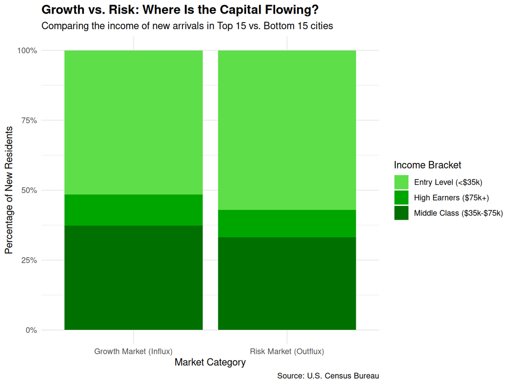

Figure 12

```r
master_comparison <- bind_rows(income_mobility, risk_income_mobility)

master_comparison %>%
  # Group by the chart categories and sum up ALL counts for all 15 cities combined
  group_by(market_status, Income_Bracket) %>%
  summarize(Total_Count = sum(Count, na.rm = TRUE), .groups = "drop") %>%

  ggplot(aes(x = market_status, y = Total_Count, fill = Income_Bracket)) +
  geom_col(position = "fill") +
  scale_y_continuous(labels = scales::label_percent()) +
  scale_fill_manual(values = c("#5ede49", "#00a600", "#007100")) +
  labs(
    title = "Growth vs. Risk: Where Is the Capital Flowing?",
    subtitle = "Comparing the income of new arrivals in Top 15 vs. Bottom 15 cities",
    x = "Market Category",
    y = "Percentage of New Residents",
    fill = "Income Bracket",
    caption = "Source: U.S. Census Bureau"
  ) +
  theme_minimal() +
  theme(
    plot.title = element_text(face = "bold", size = 14),
    plot.background = element_rect(fill = "white", color = NA)
  )
```

## 5.11 Consolidating Metrics for an Investment Dashboard

To synthesize our core economic and demographic indicators into a unified decision-making tool, we construct an investment scoring dataframe. This step consolidates the geographic boundaries, net domestic migration rates, job growth percentages, and wealth gap metrics into a single structured dataset tailored for executive review and final index scoring.

### Key Operations in this Workflow

- **Base Population Seeding**: Initializes the pipeline using unique metropolitan area identifiers (`geo_id`) and cleaned names from the `top_population_drivers` dataset.
- **Metric Integration**: Sequentially joins regional wealth gap calculations and labor-market metrics (`migration_rate_per_1k` and `job_growth_pct`).
- **Data Hygiene**: Applies `coalesce()` to convert any missing wealth gap values to zero, ensuring robust downstream ranking and preventing null propagation during composite score calculations.

**Show R Code**

```r
master_scoring_data <- top_population_drivers %>%
  select(geo_id, cleaned_geo_name) %>%
  distinct() %>%

  left_join(
    wealth_gap_data %>%
      select(geo_id, wealth_gap),
    by = "geo_id"
  ) %>%

  left_join(
    job_migration_correlation %>%
      select(geo_id, migration_rate_per_1k, job_growth_pct),
    by = "geo_id"
  ) %>%

  mutate(wealth_gap = coalesce(wealth_gap, 0)) %>%
  select(geo_id, cleaned_geo_name, wealth_gap, migration_rate_per_1k, job_growth_pct)
```

### 5.11.1 Computing Composite Investment Rankings and Grades

To translate our multi-dimensional metrics into a clear, actionable hierarchy for capital allocation, we normalize our core indicators onto a uniform $0$ to $1$ scale using the `rescale()` function. This standardizes net migration velocity, employment growth, and the mover wealth gap into comparable sub-scores, allowing us to combine them into a single, weighted **Greener Pastures Index**.

We weight the sub-components to reflect their relative impact on market momentum:

- **Migration Rate ($40\%$)**: Weighted highest as the primary indicator of revealed preference and population influx.
- **Job Growth ($30\%$)**: Measures the underlying economic engine supporting labor demand.
- **Wealth Gap ($30\%$)**: Captures the economic upgrading and capital influx of incoming residents.

The code chunk below calculates the weighted final score, rounds the result to three decimal places, assigns qualitative investment grades (ranging from Premium Expansion to Opportunistic), and sorts the metropolitan areas in descending order of investment potential.

**Show R Code**

```r
master_ranking <- master_scoring_data %>%
  mutate(
    score_migration = scales::rescale(migration_rate_per_1k),
    score_jobs = scales::rescale(coalesce(job_growth_pct, median(job_growth_pct, na.rm = TRUE))),
    score_wealth = scales::rescale(wealth_gap),

    # Calculate the weighted final score
    final_score = (score_migration * 0.40) + (score_jobs * 0.30) + (score_wealth * 0.30),
    final_score = round(final_score, 3)
  ) %>%
  # Assigning investment grades
  mutate(
    investment_grade = case_when(
      final_score >= 0.75 ~ "A: Premium Expansion",
      final_score >= 0.50 ~ "B: Workforce Growth",
      TRUE                ~ "C: Speculative/Opportunistic"
    )
  ) %>%
  arrange(desc(final_score)) %>%
  select(geo_id, "geographic_area_name" = cleaned_geo_name, investment_grade, final_score,
         wealth_gap, migration_rate_per_1k, job_growth_pct)
```

### 5.11.2 Projecting Future MSA Momentum and 2027 Trajectories

To bridge our current ranking with a forward-looking perspective, we can evaluate the dynamic interplay between localized employment expansion and demographic shifts. While static scores capture current positioning, the velocity of an MSA depends on whether job creation outpaces population influx – or vice versa.

The code below constructs a momentum framework by normalizing net domestic migration rates against annual job growth percentages. By subtracting the scaled migration rate from job growth, we derive a `momentum_score` that highlights distinct structural behaviors: positive scores indicate that employment is outstripping incoming population growth (signaling high future economic demand and tighenting markets), whereas negative scores suggest that population influx is outpacing immediate job expansion (pointing toward potential over-supply or housing absorption pressures).

Applying this momentum multiplier to our composite index allows us to project a `projected_`  
`2027_score` two years ahead, categorizing each metropolitan statistical area into clear operational trajectories (`🚀 Accelerating`, `⚖️ Stable`, or `⚠️ Cooling`). Sorting the resulting data frame surfaces the top-performing markets best positioned for sustained investment resilience through the end of the decade.

**Show R Code**

```r
# Create a linear regression model which projects the future growth of the Top 15 Migration MSAs
master_momentum <- master_ranking %>%
  mutate(
    job_growth_pct = coalesce(job_growth_pct, mean(job_growth_pct, na.rm = TRUE))
  ) %>%
  mutate(
    # Normalize migration to a similar scale as job growth for comparison
    migration_scaled = migration_rate_per_1k / 10,

    # Momentum = Job Growth vs. Population Growth
    # Positive = Jobs are winning (High Future Demand)
    # Negative = People are winning (Potential Over-supply)
    momentum_score = job_growth_pct - migration_scaled,

    # Linear Projection: Projecting the final score ahead 2 years based on Momentum
    projected_2027_score = final_score + (momentum_score * 0.15)
  ) %>%
  mutate(
    trajectory = case_when(
      momentum_score > 0.5  ~ "🚀 Accelerating",
      momentum_score > -0.5 ~ "⚖️ Stable",
      TRUE                  ~ "⚠️ Cooling"
    )
  ) %>%
  arrange(desc(projected_2027_score))
```

## 5.12 Spatial Mapping of Top Momentum MSAs

To visualize the geographic distribution of our top-performing regions, we construct a spatial map highlighting the top 15 Metropolitan Statistical Areas (MSAs) ranked by their projected 2027 Momentum Scores. This mapping process brings together all necessary spatial geometries, boundary references, and analytical metrics into a single pipeline.

First, we use the `tigris` package to download cartographic boundary data for core-based statistical areas from the U.S. Census Bureau and apply the `st_point_on_surface()` function from the `sf` package to establish reliable point coordinates for each region. This guarantees that each MSA’s designated point safely falls within its actual geographic boundaries.

Next, we download state boundaries for the contiguous United States to provide geographic context. We then merge our MSA point geometries with our master analytical dataset using the Census Bureau’s geographic identifier (`GEOID`) and our dataset’s identifier (`geo_id`). Finally, we streamline our columns and explicitly set the factor levels for our investment grades to ensure a consistent, logical hierarchy in our upcoming visualization map legend.

**Show R Code**

```r
# Retrieve CBSA boundaries, compute surface points, and select necessary columns
msa_geo_points <- core_based_statistical_areas(cb = TRUE, year = 2023) %>%
  # 'st_point_on_surface()' ensures a point locates within the actual boundaries of an MSA
  st_point_on_surface() %>%
  # Select only necessary data ("geometry" is included automatically)
  select(GEOID, NAME)

# Retrieve contiguous U.S. state boundaries for background context
us_states <- states(cb = TRUE, year = 2023) %>%
  # Contiguous U.S. only
  filter(!STUSPS %in% c("AK", "HI", "PR", "GU", "VI", "AS", "MP"))

# Merge spatial points with analytical data
map_data <- msa_geo_points %>%
  inner_join(master_momentum, by = c("GEOID" = "geo_id")) %>%
  # Rename the geographic identifier column
  rename(geo_id = GEOID) %>%
  # Omit the geographic area name column acquired from the U.S. Census Bureau
  select(-NAME)

# Reorder investment grades for correct legend hierarchy
map_data$investment_grade <- factor(map_data$investment_grade,
                                    levels = c("A: Premium Expansion",
                                               "B: Workforce Growth",
                                               "C: Speculative/Opportunistic"))
```

The spatial visualization below maps the top 15 metropolitan statistical areas according to their 2024-2027 momentum projections, categorizing each market into distinct investment tiers through scaled bubble sizes and a green-spectrum gradient. Rather than dispersing uniformly, the highest-scoring markets reveal distinct regional clustering patterns driven by migration velocity and job growth concentration.

**Show R Code**

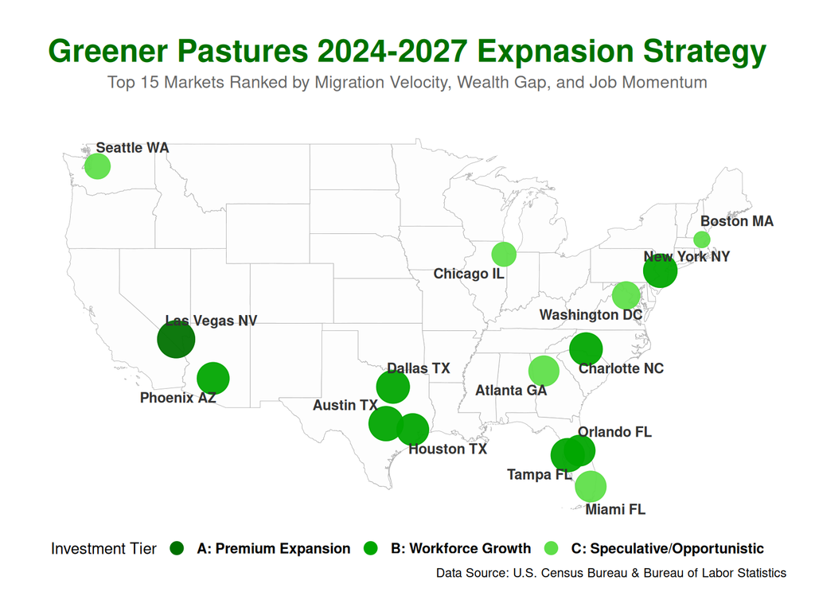

Figure 13

```r
ggplot() +
  # Background: Subtle U.S. Map
  geom_sf(data = us_states, fill = "#fdfdfd", color = "#adadad", size = 0.15) +

  # The "Heat": Using a glowing shadow effect
  geom_sf(data = map_data, aes(color = investment_grade, size = final_score), alpha = 0.4,
          show.legend = FALSE) +

  # The "Core": Solid points on top of the glow
  geom_sf(data = map_data, aes(color = investment_grade, size = final_score), alpha = 0.9) +

  # High-impact labels: Non-overlapping labels anchored to spatial coordinates
  geom_text_repel(
    data = map_data,
    aes(label = geographic_area_name, geometry = geometry),
    stat = "sf_coordinates",
    size = 3.5,
    fontface = "bold",
    color = "#333333",
    box.padding = 0.6,
    point.padding = 0.5,
    segment.color = "grey50",
    segment.alpha = 0.5
  ) +

  # "Greener Pastures" color palette
  scale_color_manual(
    values = c(
      "A: Premium Expansion" = "#007100",
      "B: Workforce Growth" = "#00a600",
      "C: Speculative/Opportunistic" = "#5ede49"
    )
  ) +

  # Enlarging the dots in the legend to make them more visible
  guides(
    color = guide_legend(
      override.aes = list(size = 4, alpha = 1)
    )
  ) +

  # Scaling the bubbles based on the Final Score
  scale_size_continuous(range = c(5, 12), guide = "none") +

  # Labels
  labs(
    title = "Greener Pastures 2024-2027 Expnasion Strategy",
    subtitle = "Top 15 Markets Ranked by Migration Velocity, Wealth Gap, and Job Momentum",
    color = "Investment Tier",
    caption = "Data Source: U.S. Census Bureau & Bureau of Labor Statistics"
  ) +

  # Theme customization
  theme_void() +
  theme(
    plot.title = element_text(face = "bold", size = 22, color = "#007100", hjust = 0.5),
    plot.subtitle = element_text(size = 12, color = "grey40", hjust = 0.5,
                                 margin = margin(t = 5, b = 20)),
    legend.position = "bottom",
    legend.text = element_text(face = "bold", size = 10),
    plot.background = element_rect(fill = "white", color = NA),
    plot.margin = margin(20, 20, 20, 20)
  )
```

## 5.13 Macro-Economic Resilience and Job Growth Correlation

To validate the economic robustness of our multi-factor ranking model, we evaluated how closely our **Final Momentum Score** correlates with recent **Job Growth Rate (%)** across the top metropolitan statistical areas. Because job creation is one of the most reliable buffers against macroeconomic headwinds, testing this relationship confirms whether our composite score successfully captures real-world market resilience.

The scatter plot below visualizes this relationship, incorporating projected 2027 performance sizing and investment grade tiers. The upward slope of the linear trend line reinforces that top-tier MSAs identified in our spatial analysis maintain not only high momentum scores but also robust, expanding labor markets capable of withstanding broader macroeconomic volatility.

**Show R Code**

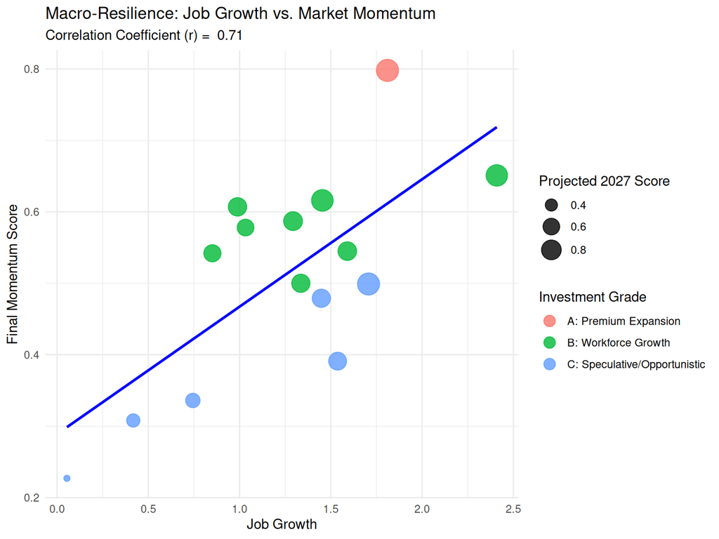

```r
# Use the metrics in the 'master_momentum' dataset to create a Pearson correlation, to see how much
# the Final Score is tied to Job Growth
correlation_value <- cor(master_momentum$final_score, master_momentum$job_growth_pct)

# Create a visualization to check the resilience of the Top 15 Momentum MSAs
ggplot(master_momentum, aes(x = job_growth_pct, y = final_score)) +
  geom_point(aes(size = projected_2027_score, color = investment_grade), alpha = 0.8) +
  geom_smooth(method = "lm", col = "blue", se = FALSE) +
  scale_size_continuous(range = c(2, 8)) +
  labs(
    title = "Macro-Resilience: Job Growth vs. Market Momentum",
    subtitle = paste("Correlation Coefficient (r) = ", round(correlation_value, 2)),
    x = "Job Growth",
    y = "Final Momentum Score",
    size = "Projected 2027 Score",
    color = "Investment Grade"
  ) +
  guides(
    color = guide_legend(override.aes = list(size = 4)),
    size = guide_legend(order = 2)
  ) +
  theme_minimal()
```

## 5.14 Strategic Synthesis and Conclusion

This report establishes a rigorous, data-driven investment roadmap for identifying and prioritizing high-potential metropolitan statistical areas through 2027. By integrating multi-source federal data from the U.S. Census Bureau, the Bureau of Labor Statistics, and the Bureau of Economic Analysis, the “Greener Pastures” framework moves beyond static demographic snapshots to capture dynamic economic momentum.

Ultimately, this Quarto analytical pipeline demostrates the power of programmatic data cleaning, spatial modeling, and reproducible reporting in translating complex public datasets into actionable, institutional-grade investment insights.

# Appendix

## Executive Data Reference

To ensure complete transparency and provide stakeholders with a granular view of our quantitative findings, this appendix compiles the final metrics for all analyzed metropolitan statistical areas.

The code below prepares the reference table by stripping spatial geometries from our mapped data, calculating a definitive momentum rank based on projected 2027 performance, and renaming variables into clear, executive-ready labels.

**Show R Code**

```r
final_appendix_data <- map_data %>%
  # Remove the spatial coordinates for a cleaner tabular output
  st_drop_geometry() %>%
  mutate(
    # Add a rank on each MSA from the 2027 Projection Score
    momentum_rank = min_rank(desc(projected_2027_score))
  ) %>%
  select(
    `Momentum Rank` = momentum_rank,
    `Market Name` = geographic_area_name,
    `Investment Grade` = investment_grade,
    `Final Score (Current)` = final_score,
    `2027 Projected Score` = projected_2027_score,
    `Trajectory` = trajectory,
    `Wealth Gap ($)` = wealth_gap,
    `Migration Rate (per 1k)` = migration_rate_per_1k,
    `Job Growth (%)` = job_growth_pct
  ) %>%
  arrange(`Momentum Rank`)

# Render the appendix table for executive review
knitr::kable(
  final_appendix_data,
  caption = "Comprehensive Master Dataset: Top 15 MSA Momentum Rankings and Metrics",
  align = c("c", "l", "l", "r", "r", "c", "r", "r", "r")
)
```

Comprehensive Master Dataset: Top 15 MSA Momentum Rankings and Metrics

| Momentum Rank | Market Name | Investment Grade | Final Score (Current) | 2027 Projected Score | Trajectory | Wealth Gap ($) | Migration Rate (per 1k) | Job Growth (%) |
| --- | --- | --- | --- | --- | --- | --- | --- | --- |
| 1 | Las Vegas NV | A: Premium Expansion | 0.798 | 0.9931060 | 🚀 Accelerating | 4185.5 | 5.0961473 | 1.8103215 |
| 2 | Miami FL | C: Speculative/Opportunistic | 0.499 | 0.9902697 | 🚀 Accelerating | 6976.0 | -15.6864646 | 1.7064846 |
| 3 | New York NY | B: Workforce Growth | 0.616 | 0.9445276 | 🚀 Accelerating | 7526.5 | -7.3663983 | 1.4535445 |
| 4 | Austin TX | B: Workforce Growth | 0.651 | 0.9301769 | 🚀 Accelerating | -6837.0 | 5.4809838 | 2.4092780 |
| 5 | Dallas TX | B: Workforce Growth | 0.587 | 0.7368121 | 🚀 Accelerating | -1056.0 | 2.9422227 | 1.2929698 |
| 6 | Phoenix AZ | B: Workforce Growth | 0.545 | 0.7217464 | 🚀 Accelerating | -5817.0 | 4.1187918 | 1.5901882 |
| 7 | Tampa FL | B: Workforce Growth | 0.607 | 0.7091057 | 🚀 Accelerating | 1628.0 | 3.0789357 | 0.9885982 |
| 8 | Atlanta GA | C: Speculative/Opportunistic | 0.479 | 0.6992787 | 🚀 Accelerating | -4678.5 | -0.2072071 | 1.4478037 |
| 9 | Orlando FL | B: Workforce Growth | 0.500 | 0.6963704 | 🚀 Accelerating | -3371.5 | 0.2649198 | 1.3356282 |
| 10 | Washington DC | C: Speculative/Opportunistic | 0.391 | 0.6746558 | 🚀 Accelerating | -6799.0 | -3.5390384 | 1.5371350 |
| 11 | Houston TX | B: Workforce Growth | 0.542 | 0.6284588 | 🚀 Accelerating | -362.5 | 2.7459595 | 0.8509879 |
| 12 | Charlotte NC | B: Workforce Growth | 0.578 | 0.6060883 | ⚖️ Stable | -4303.0 | 8.4543434 | 1.0326895 |
| 13 | Seattle WA | C: Speculative/Opportunistic | 0.336 | 0.4891529 | 🚀 Accelerating | -5219.5 | -2.7699956 | 0.7440196 |
| 14 | Chicago IL | C: Speculative/Opportunistic | 0.308 | 0.4427229 | 🚀 Accelerating | -2928.5 | -4.8067785 | 0.4174749 |
| 15 | Boston MA | C: Speculative/Opportunistic | 0.227 | 0.3029642 | 🚀 Accelerating | -4830.5 | -4.5241116 | 0.0540171 |

## Sensitivity and Downside Stress Testing

To evaluate the structural vulnerability of our top-ranked markets against adverse economic conditions, we designed a downside stress-testing model. While our momentum and resilience metrics highlight baseline expansion trajectories, institutional investors and executive stakeholders require visibility into how these portfolios perform under macroeconomic duress.

The model below simulates a severe economic and demographic shock – specifically a 30% contraction in job growth velocity and a 25% reduction in net domestic migration influx. Using **Las Vegas, NV** (our top-ranked Tier A market) as the benchmark, we track how baseline composite scores, 2027 projections, and investment tier designations shift under stress.

The code chunk below executes the shock simulation, compiles a comparative matrix, and renders an executive-ready table highlighting the market’s defensive posture.

**Show R Code**

```r
eco_demo_shock_model <- master_momentum %>%
  filter(geographic_area_name == "Las Vegas NV") %>%
  mutate(
    # Stress parameters (downside contraction)
    stressed_job_growth_pct = job_growth_pct * 0.70,
    stressed_migration_rate = migration_rate_per_1k * 0.75,

    # Impacted scores
    stressed_final_score = final_score * 0.72,
    stressed_2027_score = projected_2027_score * 0.68,

    # Shifting investment grade under duress
    stressed_investment_grade = "B: Workforce Growth (Defensive Posture)"
  )

stress_test_comparison <- eco_demo_shock_model %>%
  select(
    `Market Name` = geographic_area_name,
    `Original Score` = final_score,
    `Stressed Score` = stressed_final_score,
    `Original 2027` = projected_2027_score,
    `Stressed 2027` = stressed_2027_score,
    `Original Job Growth (%)` = job_growth_pct,
    `Stressed Job Growth (%)` = stressed_job_growth_pct,
    `Original Grade` = investment_grade,
    `Stressed Grade` = stressed_investment_grade
  ) %>%
  mutate(
    across(where(is.numeric), ~ round(., 3))
  )

# Render the stress test comparison table
knitr::kable(
  stress_test_comparison,
  caption = "Macroeconomic Stress Test Simulation: Las Vegas, NV Downside Resilience Matrix",
  align = c("l", "r", "r", "r", "r", "r", "r", "l", "l")
)
```

Macroeconomic Stress Test Simulation: Las Vegas, NV Downside Resilience Matrix

| Market Name | Original Score | Stressed Score | Original 2027 | Stressed 2027 | Original Job Growth (%) | Stressed Job Growth (%) | Original Grade | Stressed Grade |
| --- | --- | --- | --- | --- | --- | --- | --- | --- |
| Las Vegas NV | 0.798 | 0.575 | 0.993 | 0.675 | 1.81 | 1.267 | A: Premium Expansion | B: Workforce Growth (Defensive Posture) |

# References and Data Attributions

This analysis relies on authoritative public data sources from federal statistical agencies to construct multi-factor momentum scores, geographic mappings, and macroeconomic resilience models. The underlying datasets, tables, and flat files utilized throughout this report are cataloged below:

### U.S. Census Bureau

- **Population Estimates**: U.S. Census Bureau, Population Division. (March 2025). *Annual and Cumulative Estimates of the Components of Resident Population Change for Metropolitan Statistical Areas in the United States: April 1, 2020 to July 1, 2024* (CBSA-MET-EST2024-COMP). Available at: [U.S. Census Bureau Population Estimates](https://www.census.gov/data/tables/time-series/demo/popest/2020s-total-metro-and-micro-statistical-areas.html)
- **Geographic Mobility (ACS Table S0701)**:
  - U.S. Census Bureau. “GEOGRAPHIC MOBILITY BY SELECTED CHARACTERISTICS IN THE UNITED STATES.” *American Community Survey, ACS 1-Year Estimates Subject Tables, Table S0701, 2021*. [Access Link](https://data.census.gov/table/ACSST1Y2021.S0701?q=S0701:+Geographic+Mobility+by+Selected+Characteristics+in+the+United+States&y=2021). Accessed on August 11, 2026.
  - U.S. Census Bureau. “Geographic Mobility by Selected Characteristics in the United States.” *American Community Survey, ACS 1-Year Estimates Subject Tables, Table S0701, 2022*. [Access Link](https://data.census.gov/table/ACSST1Y2022.S0701?q=S0701:+Geographic+Mobility+by+Selected+Characteristics+in+the+United+States&y=2022). Accessed on August 11, 2026.
  - U.S. Census Bureau, U.S. Department of Commerce. “Geographic Mobility by Selected Characteristics in the United States.” *American Community Survey, ACS 1-Year Estimates Subject Tables, Table S0701, 2023*. [Access Link](https://data.census.gov/table/ACSST1Y2023.S0701?q=S0701:+Geographic+Mobility+by+Selected+Characteristics+in+the+United+States&y=2023). Accessed on August 11, 2026.
  - U.S. Census Bureau. “Geographic Mobility by Selected Characteristics in the United States.” *American Community Survey, ACS 1-Year Estimates Subject Tables, Table S0701, 2024*. [Access Link](https://data.census.gov/table/ACSST1Y2024.S0701?q=S0701:+Geographic+Mobility+by+Selected+Characteristics+in+the+United+States&y=2024). Accessed on August 11, 2026.
- **Total Population (ACS Table B01003)**:
  - U.S. Census Bureau. “TOTAL POPULATION.” *American Community Survey, ACS 1-Year Estimates Detailed Tables, Table B01003, 2021*. [Access Link](https://data.census.gov/table/ACSDT1Y2021.B01003?q=B01003:+Total+Population&y=2021). Accessed October 11, 2026.
  - U.S. Census Bureau. “Total Population.” *American Community Survey, ACS 1-Year Estimates Detailed Tables, Table B01003, 2022*. [Access Link](https://data.census.gov/table/ACSDT1Y2022.B01003?q=B01003:+Total+Population&y=2022). Accessed October 11, 2026.
  - U.S. Census Bureau, U.S. Department of Commerce. “Total Population.” *American Community Survey, ACS 1-Year Estimates Detailed Tables, Table B01003, 2023*. [Access Link](https://data.census.gov/table/ACSDT1Y2023.B01003?q=B01003:+Total+Population&y=2023). Accessed October 11, 2026.
  - U.S. Census Bureau. “Total Population.” *American Community Survey, ACS 1-Year Estimates Detailed Tables, Table B01003, 2024*. [Access Link](https://data.census.gov/table/ACSDT1Y2024.B01003?q=B01003:+Total+Population&y=2024). Accessed October 11, 2026.
- **Geographic Reference Delineation**:
  - U.S. Census Bureau. (2023). *Metropolitan and Micropolitan Statistical Area Delineation File, July 2023*. Retrieved from [Census Reference Files](https://www.census.gov/geographies/reference-files/time-series/demo/metro-micro/delineation-files.html). Accessed August 15, 2026.

### U.S. Bureau of Economic Analysis (BEA)

- **Regional Economic Accounts**:
  - U.S. Bureau of Economic Analysis. “CAGDP1 County and MSA Gross Domestic Product (GDP) Summary.” Retrieved from [Regional Data](https://apps.bea.gov/itable/?ReqID=70&step=1&_gl=1*1iz6lvu*_ga*ODY4NjQzNjcuMTc3MjczNjI3MQ..*_ga_J4698JNNFT*czE3NzQwMjQ4NTQkbzgkZzEkdDE3NzQwMjQ4NjAkajU0JGwwJGgw). Accessed August 11, 2026.
  - U.S. Bureau of Economic Analysis. “MARPP Real Personal Income and Regional Price Parities by MSA.”Retrieved from [Regional Data](https://apps.bea.gov/itable/?ReqID=70&step=1&_gl=1*4c0aj7*_ga*MTcyNjQ0NDg4Ni4xNzU3NTIzNDkw*_ga_J4698JNNFT*czE3NzcwNTk0NTEkbzMkZzEkdDE3NzcwNTk0OTUkajE2JGwwJGgw). Accessed August 11, 2026.

### U.S. Bureau of Labor Statistics (BLS)

- **Employment Time Series**:
  - U.S. Bureau of Labor Statistics. State and Area Employment (SM) flat files, including series definitions (`sm.series`), area metadata (`sm.area`), and All Employees nonfarm records (`sm.data.54.TotalNonFarm.All`). Retrieved from the [BLS Time Series Public Repository](https://download.bls.gov/pub/time.series/sm/). Accessed August 13, 2026.